fossil

# Pathway activity from condition-responsive genes, dug back up.

53 results: 4 exact, 15 agree, 26 partly agree, 6 differ, 2 not attempted. The lost method was rebuilt from the paper's Methods, and the seven datasets from GEO, Bioconductor and the GSEA site.

See every result

## Fig. 2

Fig. 2. Mean |t| of the top 1% to 10% pathway markers (PAC, PAC_all), their CORGs and as many top genes, in the dataset the markers come from (A, C, E, G) and in the other cohort (B, D, F, H). Ours drawn in the published colours.

Partly agreeson review

Published

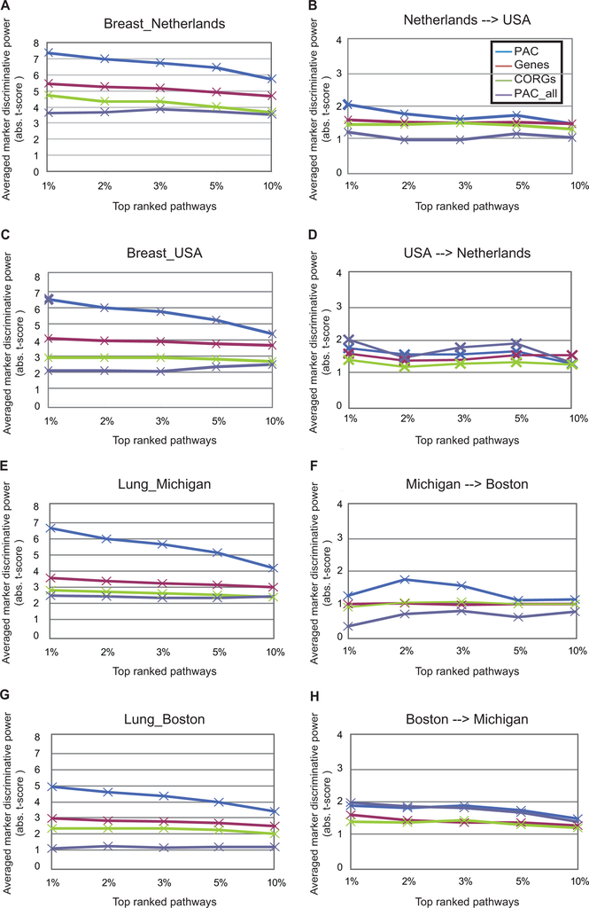

Our run, on the published axes

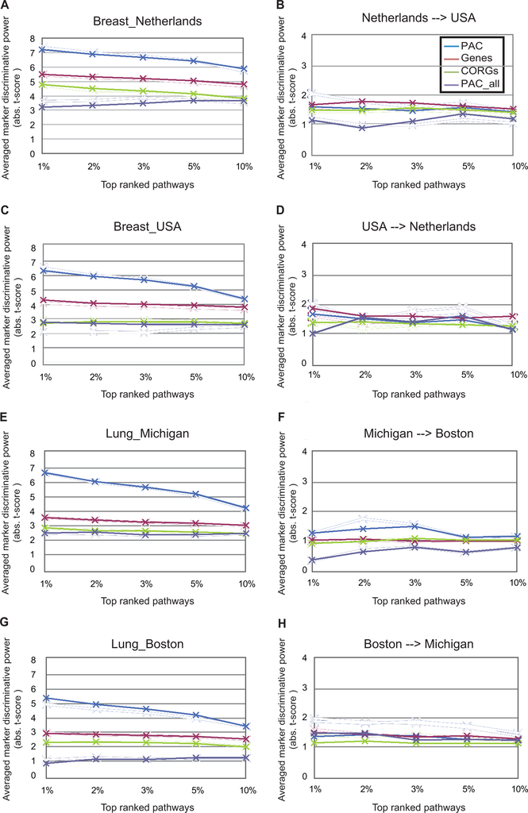

**Fig. 2A**

11 of 20 values, Agrees

**Fig. 2B**

7 of 18 values, Partly agrees

**Fig. 2C**

7 of 17 values, Agrees

**Fig. 2D**

9 of 19 values, Partly agrees

**Fig. 2E**

19 of 20 values, Agrees

**Fig. 2F**

17 of 18 values, Agrees

**Fig. 2G**

14 of 20 values, Agrees

**Fig. 2H**

5 of 20 values, Partly agrees

The breast datasets' preprocessing and probe-to-gene mapping are not stated, and our breast data are not the paper's: only 3 of Table S2's 15 CORG lists come back. The source curves (A, C) keep the published shape and order; the verification curves (B, D) differ by up to 1.0. One point is off: PAC_all at 2% reads 2.43 on the figure and 2.55 in our run; the other 19 are within 0.1. One point is off: PAC at 2% reads 1.73 on the figure and 1.37 in our run (the paper's curve rises at 2% and falls again); every other readable point is within 0.1. Boston's top pathways are not those of Tian's statistic on the GSEA Boston file: Table 1's Boston-to-Michigan pathways rank as low as 375th in it. The Boston CORGs themselves are exact (Table 1), so the difference is in which pathways are ranked; our PAC is up to 0.43 above the figure in G and up to 0.54 below it in H.

## Fig. 3

Fig. 3. AUC of logistic-regression classifiers over 100 runs of 5-fold cross-validation, within datasets (A) and across datasets (B). Our bars in the published colours; -log(p) labels are the paper's.

Differson review

Published

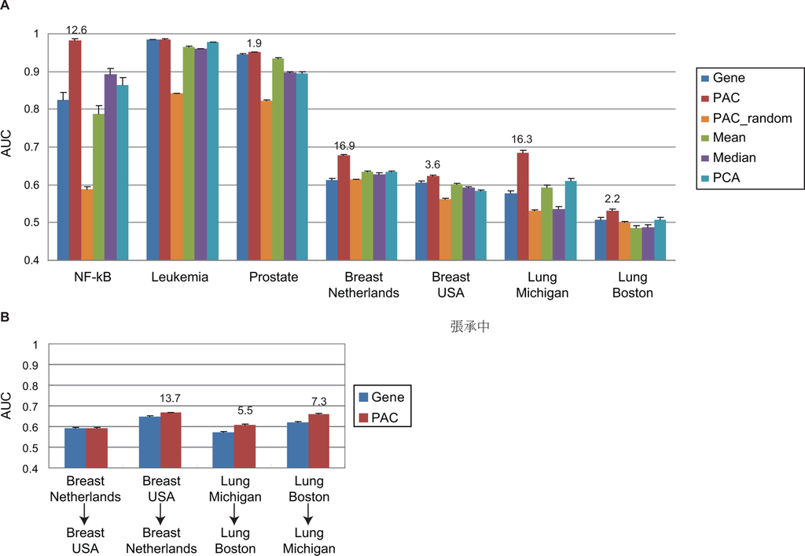

Our run, on the published axes

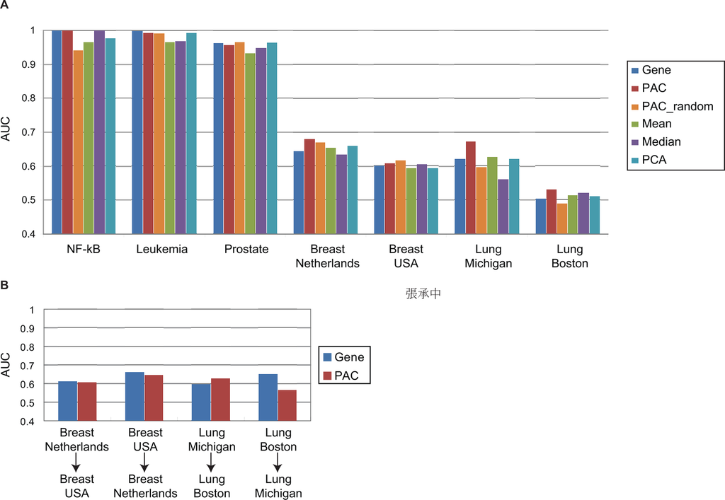

**Fig. 3A, AUC within datasets (bar heights)**

23 of 42 values, Agrees

**Fig. 3B, AUC across datasets (bar heights)**

5 of 8 values, Agrees

**Fig. 3, -log(p) of PAC against Gene (printed labels)**

0 of 9 values, Differs

23 of 42 bars within 0.02. PAC_random differs because the paper's random sets skip the CORG search (supported); NF-kB is near 1 for every method in our data (open); the rest differ by up to 0.07 with unstated classifier settings. 5 of 8 bars within 0.02. Boston to Michigan: our PAC is 0.56 against 0.66; the paper's Boston markers were not Tian's top 52 (a sensitivity run without the pre-selection gives PAC 0.71); the Gene bars of both lung directions are 0.02 to 0.03 high. -log10 p of a Wilcoxon test on 500 paired AUCs moves with every unstated setting and with the random partitions; no printed value comes back to its decimal. Where both are significant the sizes are close (Breast Netherlands 19.2 against 16.9); the significance pattern is compared in text.pac_beats_gene_within and _across.

## Fig. 4

Fig. 4. Activity of the Table 1 pathways in the two lung datasets, poor-prognosis patients first, red for high and green for low. Ours is painted into the published heatmaps, our patients matched one to one to the published columns; what is scored is each row's direction and whether it follows the published row patient by patient.

Agrees

Published

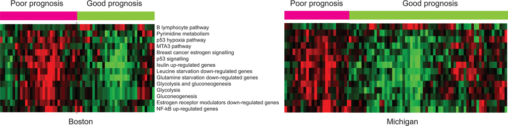

Our run, on the published axes

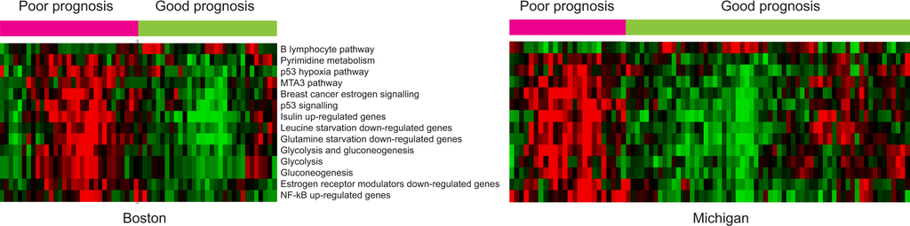

**Fig. 4, each pathway's activity in poor prognosis and patient by patient (lung)**

56 of 56 values, Agrees

## Fig. S1

Fig. S1. Overlap of the top markers between the two halves of 100 random splits: pathways, their CORGs and genes.

Partly agrees

Published

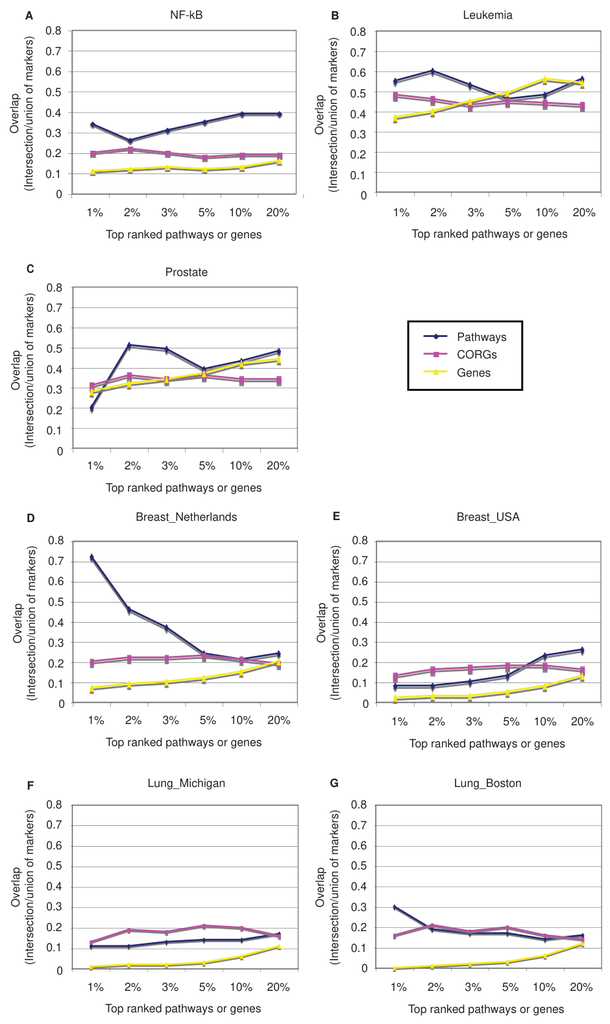

Our run, on the published axes

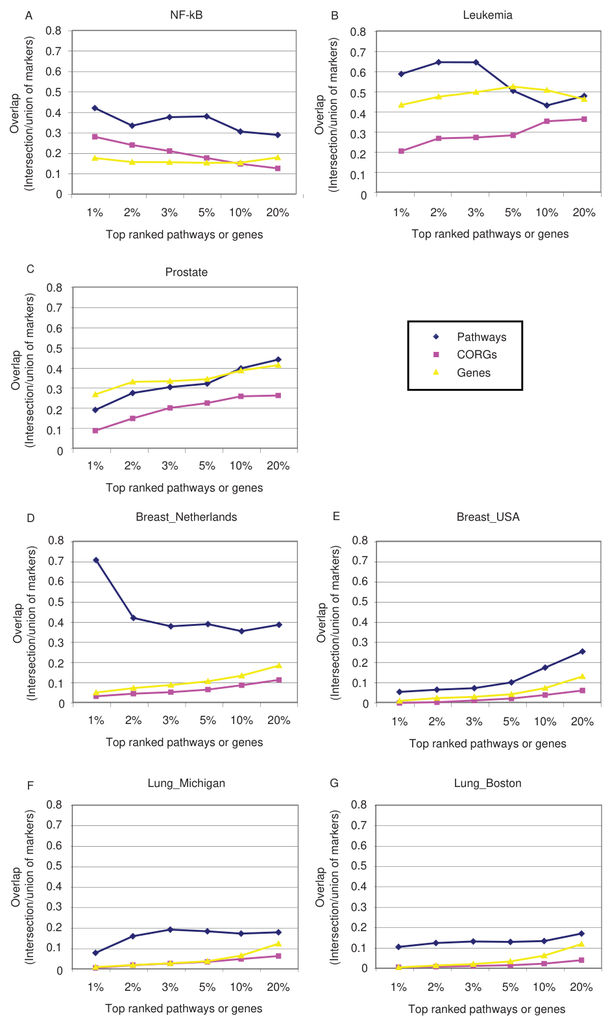

**Fig. S1, marker overlap over 100 two-fold splits, NF-kB**

10 of 18 values, Partly agrees

**Fig. S1, marker overlap over 100 two-fold splits, Leukemia**

6 of 18 values, Partly agrees

**Fig. S1, marker overlap over 100 two-fold splits, Prostate**

9 of 18 values, Partly agrees

**Fig. S1, marker overlap over 100 two-fold splits, Breast Netherlands**

9 of 18 values, Partly agrees

**Fig. S1, marker overlap over 100 two-fold splits, Breast USA**

11 of 18 values, Partly agrees

**Fig. S1, marker overlap over 100 two-fold splits, Lung Michigan**

10 of 18 values, Partly agrees

**Fig. S1, marker overlap over 100 two-fold splits, Lung Boston**

10 of 18 values, Partly agrees

The pathway and gene curves follow the figure within about 0.1 at most points. The paper does not say how the CORG overlap was computed: ours is close to the figure for NF-kB and below it in the other six datasets (0 to 0.12 against 0.13 to 0.23 in the breast and lung sets).

## Fig. S2

Fig. S2. Fig. 3 with k-nearest neighbours (k = 3, 5; accuracy), naive Bayes and LDA (AUC).

Differs

Published

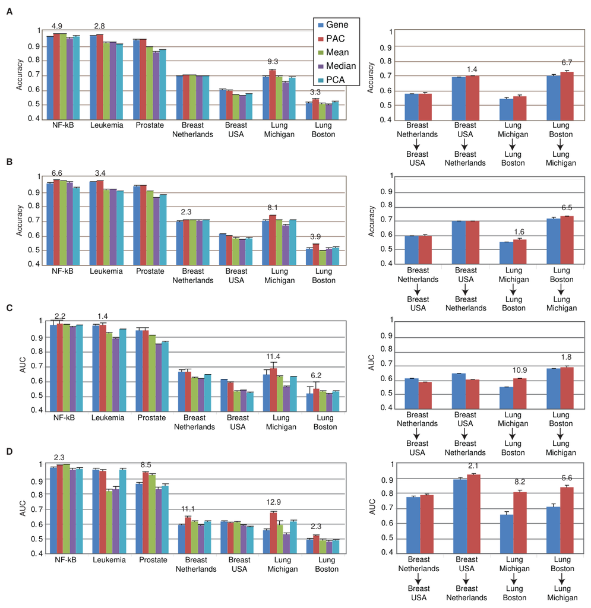

Our run, on the published axes

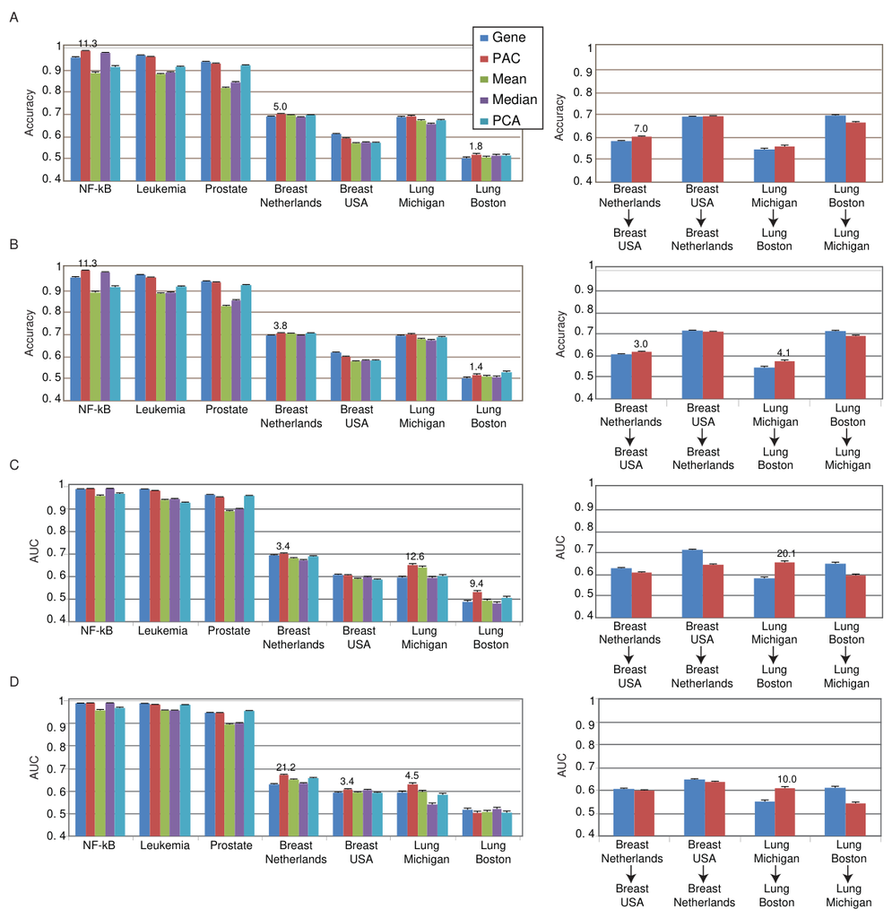

**Fig. S2A, kNN, k = 3 (bar heights)**

30 of 43 values, Partly agrees

**Fig. S2A, kNN, k = 3, -log(p) labels**

0 of 6 values, Differs

**Fig. S2B, kNN, k = 5 (bar heights)**

32 of 43 values, Partly agrees

**Fig. S2B, kNN, k = 5, -log(p) labels**

0 of 7 values, Differs

**Fig. S2C, naive Bayes (bar heights)**

13 of 43 values, Partly agrees

**Fig. S2C, naive Bayes, -log(p) labels**

0 of 6 values, Differs

**Fig. S2D, LDA (bar heights)**

14 of 43 values, Partly agrees

**Fig. S2D, LDA, -log(p) labels**

0 of 8 values, Differs

The classifiers' settings (distance and ties for kNN, the naive Bayes model, LDA's covariance) are not stated; NF-kB and Leukemia are near 1 in our data; our bars differ by up to 0.3 (Lung Boston to Michigan with LDA). -log10 p of a Wilcoxon test on 500 paired AUCs moves with every unstated setting and with the random partitions; no printed value comes back to its decimal. Where both are significant the sizes are close (Breast Netherlands 19.2 against 16.9); the significance pattern is compared in text.pac_beats_gene_within and _across.

## Fig. S3

Fig. S3. Sequential against forward selection, logistic regression, within datasets.

Partly agrees

Published

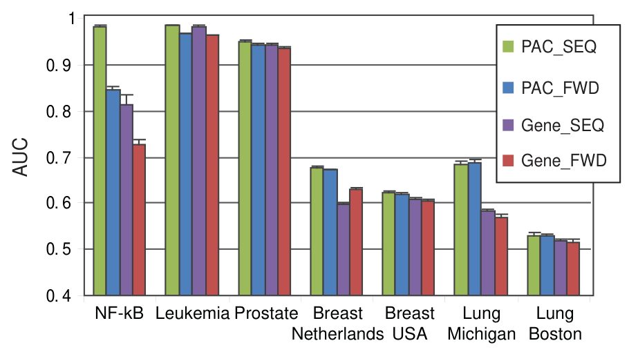

Our run, on the published axes

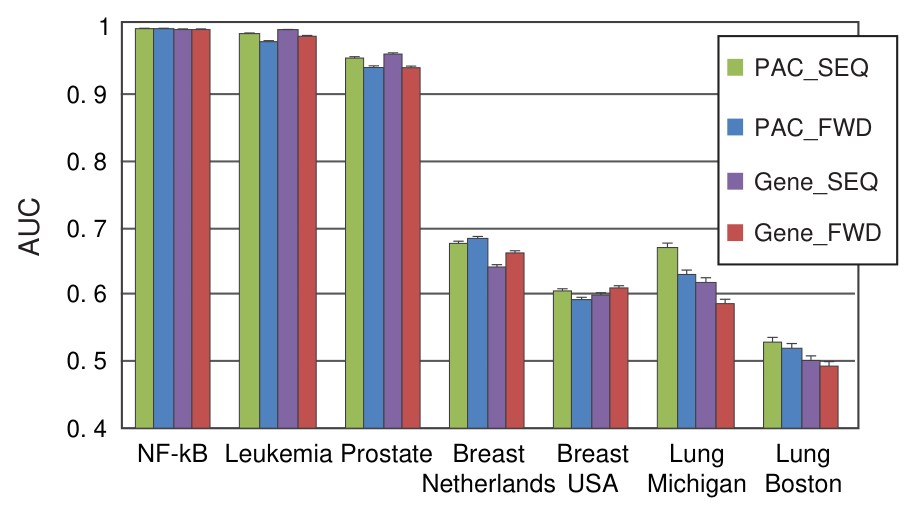

**Fig. S3, sequential against forward selection**

18 of 28 values, Partly agrees

18 of 28 bars within 0.02. The forward selection's stopping rule is not stated; NF-kB is near 1 for every method in our data.

## Fig. S4

Fig. S4. As Fig. 4 for the Table S2 pathways in the two breast datasets, metastatic patients first; its cells are too narrow to read one by one, so each class is ordered by its patients' mean activity and only each row's direction is scored.

Partly agrees

Published

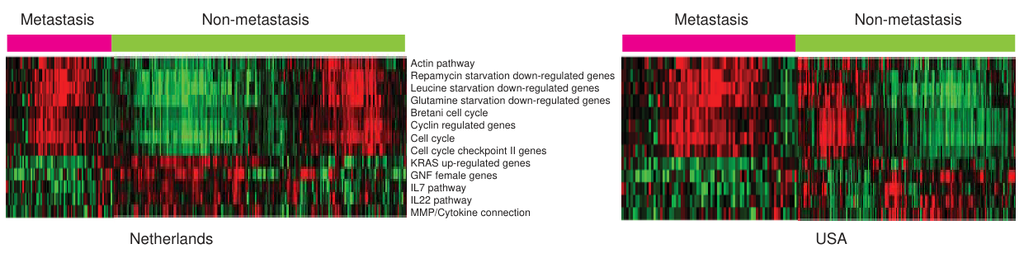

Our run, on the published axes

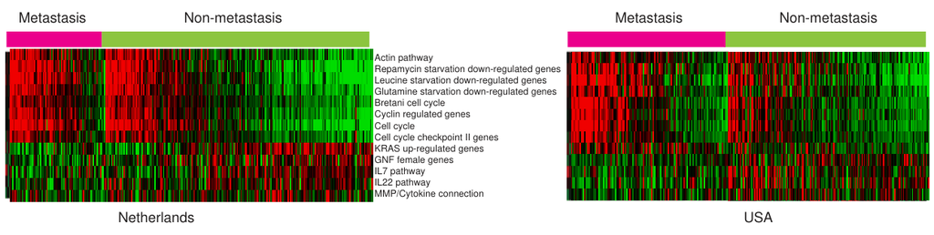

**Fig. S4, each pathway's activity higher or lower in metastasis (breast)**

25 of 26 values, Partly agrees

25 of 26 rows go the same way as the published heatmaps. The miss is KRAS up-regulated genes in Breast USA: the heatmap uses each dataset's own CORGs, and ours for this set (COL4A1 TUFT1 TGFBI) are not the paper's (TUFT1 P4HA2 COL4A1), because our USA data are not the authors'.

## Fig. S5

Fig. S5. Number of CORGs of each of the top 10% pathways in each dataset.

Partly agrees

Published

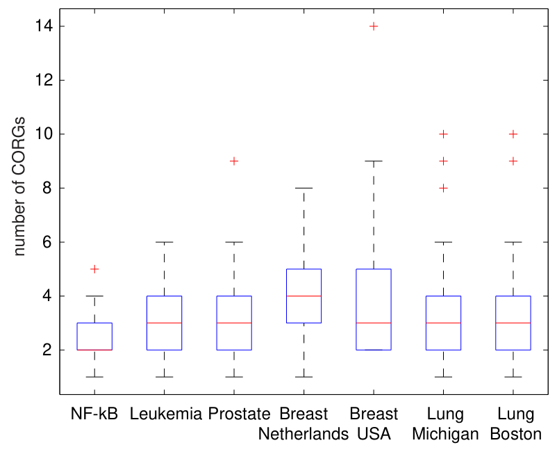

Our run, on the published axes

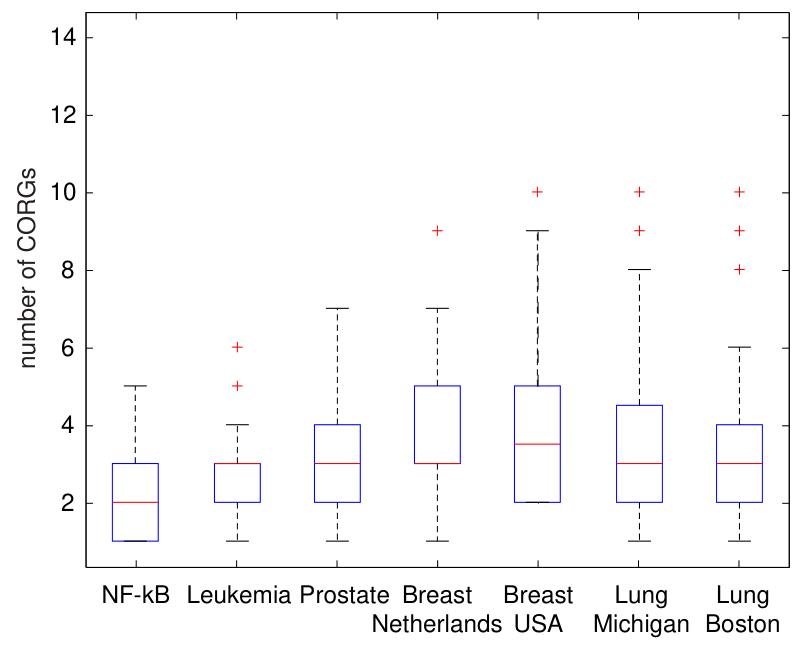

**Fig. S5, CORGs per pathway in the top 10%**

25 of 42 values, Partly agrees

The box plots summarize the CORG counts of each dataset's top 52 pathways; the medians come back in 5 of 7 datasets. Which 52 pathways the paper counted is not certain (Boston's differ, fig2.g), and the breast data differ.

## Every result

Every figure, table and claim of the paper. Figure values are read off the published figures (Figs 2 and 3) or the vector supplements (Figs S1 to S5); a value agrees within 0.1 |t| (Fig. 2), 0.02 AUC (Figs 3, S2, S3), 0.05 overlap (Fig. S1) or 50 of 500 classifiers (frequencies).

Result

Verdict

Measure

Why

Fig. 1, schematic of CORG identification

Not attempted

A diagram of the method; there is nothing to recompute.

Table S1, class sizes of the seven datasets

Partly agrees

12 of 14 values

- NF-kB Wildtype: paper 12, ours **12**
- NF-kB Mutant: paper 12, ours **12**
- Prostate Normal: paper 41, ours **41**
- Prostate Cancer: paper 62, ours **62**
- Leukemia TEL-AML1: paper 79, ours **79**
- Leukemia HH: paper 64, ours **64**
- Breast Netherlands Metastatic: paper 78, ours **78**
- Breast Netherlands Non-metastatic: paper 217, ours **217**
- Breast USA Metastatic: paper 106, ours **107**
- Breast USA Non-metastatic: paper 180, ours **179**
- Lung Boston Poor: paper 31, ours **31**
- Lung Boston Good: paper 31, ours **31**
- Lung Michigan Poor: paper 24, ours **24**
- Lung Michigan Good: paper 62, ours **62**

GEO's clinical table for GSE2034 has 107 patients with a distant relapse and 179 without; the paper (and GEO's series summary) say 106 and 180. All other class sizes come back.

Methods: MSigDB v1.0 C2 gene sets, genes and the top 10%

Exact

3 of 3 values

- C2 gene sets: paper 522, ours **522**
- genes in C2: paper 5602, ours **5602**
- top 10% of pathways: paper 52, ours **52**

Fig. 2A

Agreeson review

11 of 20 values

- PAC top 1%: paper 7.29, ours **7.1968**
- PAC top 2%: paper 7.02, ours **6.8804**
- PAC top 3%: paper 6.774, ours **6.6718**
- PAC top 5%: paper 6.479, ours **6.4276**
- PAC top 10%: paper 5.765, ours **5.8741**
- Genes top 1%: paper 5.47, ours **5.4778**
- Genes top 2%: paper 5.286, ours **5.3197**
- Genes top 3%: paper 5.187, ours **5.1796**
- Genes top 5%: paper 4.942, ours **5.0295**
- Genes top 10%: paper 4.708, ours **4.7839**
- CORGs top 1%: paper 4.855, ours **4.7692**
- CORGs top 2%: paper 4.364, ours **4.4996**
- CORGs top 3%: paper 4.364, ours **4.3301**
- CORGs top 5%: paper 4.032, ours **4.1184**
- CORGs top 10%: paper 3.712, ours **3.8218**
- PAC_all top 1%: paper 3.65, ours **3.1864**
- PAC_all top 2%: paper 3.7, ours **3.3254**
- PAC_all top 3%: paper 3.884, ours **3.4646**
- PAC_all top 5%: paper 3.712, ours **3.6542**
- PAC_all top 10%: paper 3.54, ours **3.6438**

The breast datasets' preprocessing and probe-to-gene mapping are not stated, and our breast data are not the paper's: only 3 of Table S2's 15 CORG lists come back. The source curves (A, C) keep the published shape and order; the verification curves (B, D) differ by up to 1.0.

Fig. 2B

Partly agreeson review

7 of 18 values

- PAC top 1%: paper 2.049, ours **1.577**
- PAC top 2%: paper 1.761, ours **1.5187**
- PAC top 3%: paper 1.595, ours **1.447**
- PAC top 5%: paper 1.718, ours **1.554**
- Genes top 1%: paper 1.571, ours **1.6549**
- Genes top 2%: paper 1.515, ours **1.7682**
- Genes top 5%: paper 1.503, ours **1.6119**
- Genes top 10%: paper 1.454, ours **1.5143**
- CORGs top 1%: paper 1.429, ours **1.4755**
- CORGs top 2%: paper 1.429, ours **1.4581**
- CORGs top 3%: paper 1.472, ours **1.545**
- CORGs top 5%: paper 1.405, ours **1.4859**
- CORGs top 10%: paper 1.282, ours **1.3887**
- PAC_all top 1%: paper 1.184, ours **1.1218**
- PAC_all top 2%: paper 0.951, ours **0.8504**
- PAC_all top 3%: paper 0.951, ours **1.0749**
- PAC_all top 5%: paper 1.141, ours **1.3435**
- PAC_all top 10%: paper 1.025, ours **1.1702**

The breast datasets' preprocessing and probe-to-gene mapping are not stated, and our breast data are not the paper's: only 3 of Table S2's 15 CORG lists come back. The source curves (A, C) keep the published shape and order; the verification curves (B, D) differ by up to 1.0.

Fig. 2C

Agreeson review

7 of 17 values

- PAC top 2%: paper 6.016, ours **5.9237**
- PAC top 3%: paper 5.759, ours **5.6737**
- PAC top 5%: paper 5.233, ours **5.2406**
- PAC top 10%: paper 4.449, ours **4.3678**
- Genes top 1%: paper 4.094, ours **4.2873**
- Genes top 2%: paper 3.948, ours **4.058**
- Genes top 3%: paper 3.911, ours **3.9891**
- Genes top 5%: paper 3.764, ours **3.9161**
- Genes top 10%: paper 3.666, ours **3.806**
- CORGs top 1%: paper 2.907, ours **2.6757**
- CORGs top 2%: paper 2.907, ours **2.7979**
- CORGs top 3%: paper 2.907, ours **2.7778**
- CORGs top 5%: paper 2.809, ours **2.767**
- CORGs top 10%: paper 2.687, ours **2.664**
- PAC_all top 2%: paper 2.074, ours **2.6813**
- PAC_all top 3%: paper 2.05, ours **2.5898**
- PAC_all top 5%: paper 2.332, ours **2.6012**

The breast datasets' preprocessing and probe-to-gene mapping are not stated, and our breast data are not the paper's: only 3 of Table S2's 15 CORG lists come back. The source curves (A, C) keep the published shape and order; the verification curves (B, D) differ by up to 1.0.

Fig. 2D

Partly agreeson review

9 of 19 values

- PAC top 1%: paper 1.747, ours **1.6635**
- PAC top 2%: paper 1.57, ours **1.5017**
- PAC top 3%: paper 1.558, ours **1.369**
- PAC top 5%: paper 1.668, ours **1.4621**
- PAC top 10%: paper 1.321, ours **1.1459**
- Genes top 1%: paper 1.577, ours **1.8599**
- Genes top 2%: paper 1.352, ours **1.6016**
- Genes top 3%: paper 1.388, ours **1.594**
- Genes top 5%: paper 1.534, ours **1.5263**
- Genes top 10%: paper 1.534, ours **1.5866**
- CORGs top 1%: paper 1.394, ours **1.3644**
- CORGs top 2%: paper 1.175, ours **1.3992**
- CORGs top 3%: paper 1.273, ours **1.337**
- CORGs top 5%: paper 1.315, ours **1.2997**
- CORGs top 10%: paper 1.242, ours **1.2459**
- PAC_all top 1%: paper 2.014, ours **0.996**
- PAC_all top 2%: paper 1.461, ours **1.5497**
- PAC_all top 3%: paper 1.771, ours **1.3894**
- PAC_all top 5%: paper 1.899, ours **1.6044**

The breast datasets' preprocessing and probe-to-gene mapping are not stated, and our breast data are not the paper's: only 3 of Table S2's 15 CORG lists come back. The source curves (A, C) keep the published shape and order; the verification curves (B, D) differ by up to 1.0.

Fig. 2E

Agreeson review

19 of 20 values

- PAC top 1%: paper 6.683, ours **6.6762**
- PAC top 2%: paper 6.009, ours **6.0615**
- PAC top 3%: paper 5.678, ours **5.6753**
- PAC top 5%: paper 5.151, ours **5.2076**
- PAC top 10%: paper 4.194, ours **4.2177**
- Genes top 1%: paper 3.569, ours **3.5588**
- Genes top 2%: paper 3.385, ours **3.3836**
- Genes top 3%: paper 3.25, ours **3.2406**
- Genes top 5%: paper 3.14, ours **3.1696**
- Genes top 10%: paper 2.993, ours **3.0253**
- CORGs top 1%: paper 2.809, ours **2.8348**
- CORGs top 2%: paper 2.711, ours **2.6503**
- CORGs top 3%: paper 2.613, ours **2.6201**
- CORGs top 5%: paper 2.564, ours **2.5492**
- CORGs top 10%: paper 2.38, ours **2.4457**
- PAC_all top 1%: paper 2.466, ours **2.4729**
- PAC_all top 2%: paper 2.429, ours **2.5452**
- PAC_all top 3%: paper 2.343, ours **2.3458**
- PAC_all top 5%: paper 2.331, ours **2.371**
- PAC_all top 10%: paper 2.49, ours **2.4552**

One point is off: PAC_all at 2% reads 2.43 on the figure and 2.55 in our run; the other 19 are within 0.1.

Fig. 2F

Agreeson review

17 of 18 values

- PAC top 1%: paper 1.228, ours **1.2254**
- PAC top 2%: paper 1.728, ours **1.3721**
- PAC top 3%: paper 1.543, ours **1.4651**
- PAC top 5%: paper 1.099, ours **1.0744**
- PAC top 10%: paper 1.173, ours **1.1175**
- Genes top 1%: paper 0.963, ours **0.9774**
- Genes top 2%: paper 0.969, ours **1.0207**
- Genes top 3%: paper 0.926, ours **0.9505**
- CORGs top 1%: paper 0.87, ours **0.8691**
- CORGs top 2%: paper 1.012, ours **0.938**
- CORGs top 3%: paper 1.037, ours **1.0455**
- CORGs top 5%: paper 0.963, ours **0.9778**
- CORGs top 10%: paper 1.031, ours **0.9953**
- PAC_all top 1%: paper 0.265, ours **0.2915**
- PAC_all top 2%: paper 0.654, ours **0.5717**
- PAC_all top 3%: paper 0.753, ours **0.7289**
- PAC_all top 5%: paper 0.556, ours **0.5661**
- PAC_all top 10%: paper 0.784, ours **0.7278**

One point is off: PAC at 2% reads 1.73 on the figure and 1.37 in our run (the paper's curve rises at 2% and falls again); every other readable point is within 0.1.

Fig. 2G

Agreeson review

14 of 20 values

- PAC top 1%: paper 4.942, ours **5.3693**
- PAC top 2%: paper 4.61, ours **4.9383**
- PAC top 3%: paper 4.364, ours **4.6039**
- PAC top 5%: paper 3.982, ours **4.1911**
- PAC top 10%: paper 3.392, ours **3.3942**
- Genes top 1%: paper 2.962, ours **2.9156**
- Genes top 2%: paper 2.814, ours **2.8305**
- Genes top 3%: paper 2.777, ours **2.753**
- Genes top 5%: paper 2.679, ours **2.6803**
- Genes top 10%: paper 2.495, ours **2.5163**
- CORGs top 1%: paper 2.347, ours **2.2807**
- CORGs top 2%: paper 2.347, ours **2.3227**
- CORGs top 3%: paper 2.347, ours **2.2656**
- CORGs top 5%: paper 2.236, ours **2.1991**
- CORGs top 10%: paper 2.015, ours **1.9818**
- PAC_all top 1%: paper 1.093, ours **0.8272**
- PAC_all top 2%: paper 1.24, ours **1.1203**
- PAC_all top 3%: paper 1.13, ours **1.0913**
- PAC_all top 5%: paper 1.179, ours **1.2041**
- PAC_all top 10%: paper 1.191, ours **1.2228**

Boston's top pathways are not those of Tian's statistic on the GSEA Boston file: Table 1's Boston-to-Michigan pathways rank as low as 375th in it. The Boston CORGs themselves are exact (Table 1), so the difference is in which pathways are ranked; our PAC is up to 0.43 above the figure in G and up to 0.54 below it in H.

Fig. 2H

Partly agreeson review

5 of 20 values

- PAC top 1%: paper 1.881, ours **1.342**
- PAC top 2%: paper 1.808, ours **1.4087**
- PAC top 3%: paper 1.888, ours **1.371**
- PAC top 5%: paper 1.746, ours **1.2546**
- PAC top 10%: paper 1.476, ours **1.2224**
- Genes top 1%: paper 1.593, ours **1.488**
- Genes top 2%: paper 1.434, ours **1.4349**
- Genes top 3%: paper 1.348, ours **1.3393**
- Genes top 5%: paper 1.36, ours **1.3675**
- Genes top 10%: paper 1.274, ours **1.2593**
- CORGs top 1%: paper 1.384, ours **1.1305**
- CORGs top 2%: paper 1.36, ours **1.1864**
- CORGs top 3%: paper 1.427, ours **1.1132**
- CORGs top 5%: paper 1.286, ours **1.098**
- CORGs top 10%: paper 1.188, ours **1.1185**
- PAC_all top 1%: paper 1.967, ours **1.4564**
- PAC_all top 2%: paper 1.851, ours **1.4699**
- PAC_all top 3%: paper 1.814, ours **1.229**
- PAC_all top 5%: paper 1.667, ours **1.2552**
- PAC_all top 10%: paper 1.378, ours **1.2142**

Boston's top pathways are not those of Tian's statistic on the GSEA Boston file: Table 1's Boston-to-Michigan pathways rank as low as 375th in it. The Boston CORGs themselves are exact (Table 1), so the difference is in which pathways are ranked; our PAC is up to 0.43 above the figure in G and up to 0.54 below it in H.

Fig. 3A, AUC within datasets (bar heights)

Agreeson review

23 of 42 values

- NF-kB Gene: paper 0.8239, ours **0.9978**
- NF-kB PAC: paper 0.9828, ours **0.9992**
- NF-kB PAC_random: paper 0.5862, ours **0.9403**
- NF-kB Mean: paper 0.7866, ours **0.9645**
- NF-kB Median: paper 0.8926, ours **0.999**
- NF-kB PCA: paper 0.8639, ours **0.9762**
- Leukemia Gene: paper 0.9828, ours **0.9978**
- Leukemia PAC: paper 0.9842, ours **0.9918**
- Leukemia PAC_random: paper 0.841, ours **0.9894**
- Leukemia Mean: paper 0.9642, ours **0.9642**
- Leukemia Median: paper 0.9599, ours **0.9673**
- Leukemia PCA: paper 0.977, ours **0.991**
- Prostate Gene: paper 0.9455, ours **0.9611**
- Prostate PAC: paper 0.9498, ours **0.9551**
- Prostate PAC_random: paper 0.8224, ours **0.9643**
- Prostate Mean: paper 0.9341, ours **0.9317**
- Prostate Median: paper 0.8969, ours **0.947**
- Prostate PCA: paper 0.894, ours **0.9627**
- Breast Netherlands Gene: paper 0.6105, ours **0.6418**
- Breast Netherlands PAC: paper 0.6764, ours **0.6771**
- Breast Netherlands PAC_random: paper 0.612, ours **0.6672**
- Breast Netherlands Mean: paper 0.6334, ours **0.6525**
- Breast Netherlands Median: paper 0.6263, ours **0.6318**
- Breast Netherlands PCA: paper 0.6334, ours **0.6573**
- Breast USA Gene: paper 0.6048, ours **0.5997**
- Breast USA PAC: paper 0.622, ours **0.6058**
- Breast USA PAC_random: paper 0.5604, ours **0.6148**
- Breast USA Mean: paper 0.5991, ours **0.5914**
- Breast USA Median: paper 0.5905, ours **0.604**
- Breast USA PCA: paper 0.5819, ours **0.5917**
- Lung Michigan Gene: paper 0.5762, ours **0.6186**
- Lung Michigan PAC: paper 0.6835, ours **0.671**
- Lung Michigan PAC_random: paper 0.5289, ours **0.5947**
- Lung Michigan Mean: paper 0.5905, ours **0.625**
- Lung Michigan Median: paper 0.5347, ours **0.5591**
- Lung Michigan PCA: paper 0.6091, ours **0.6186**
- Lung Boston Gene: paper 0.506, ours **0.5016**
- Lung Boston PAC: paper 0.5289, ours **0.5291**
- Lung Boston PAC_random: paper 0.4989, ours **0.4878**
- Lung Boston Mean: paper 0.4831, ours **0.512**
- Lung Boston Median: paper 0.486, ours **0.5193**
- Lung Boston PCA: paper 0.506, ours **0.5089**

23 of 42 bars within 0.02. PAC_random differs because the paper's random sets skip the CORG search (supported); NF-kB is near 1 for every method in our data (open); the rest differ by up to 0.07 with unstated classifier settings.

Fig. 3B, AUC across datasets (bar heights)

Agreeson review

5 of 8 values

- Breast Netherlands -> Breast USA Gene: paper 0.591, ours **0.6089**
- Breast Netherlands -> Breast USA PAC: paper 0.591, ours **0.6048**
- Breast USA -> Breast Netherlands Gene: paper 0.6458, ours **0.6582**
- Breast USA -> Breast Netherlands PAC: paper 0.664, ours **0.6441**
- Lung Michigan -> Lung Boston Gene: paper 0.5701, ours **0.5927**
- Lung Michigan -> Lung Boston PAC: paper 0.6067, ours **0.6246**
- Lung Boston -> Lung Michigan Gene: paper 0.6197, ours **0.6483**
- Lung Boston -> Lung Michigan PAC: paper 0.6588, ours **0.5622**

5 of 8 bars within 0.02. Boston to Michigan: our PAC is 0.56 against 0.66; the paper's Boston markers were not Tian's top 52 (a sensitivity run without the pre-selection gives PAC 0.71); the Gene bars of both lung directions are 0.02 to 0.03 high.

Fig. 3, -log(p) of PAC against Gene (printed labels)

Differs

0 of 9 values

- NF-kB -log10 p: paper 12.6, ours **0.5217**
- Prostate -log10 p: paper 1.9, ours **2.7625**
- Breast Netherlands -log10 p: paper 16.9, ours **19.2488**
- Breast USA -log10 p: paper 3.6, ours **1.0166**
- Lung Michigan -log10 p: paper 16.3, ours **8.5067**
- Lung Boston -log10 p: paper 2.2, ours **3.095**
- Breast USA -> Breast Netherlands -log10 p: paper 13.7, ours **3.6286**
- Lung Michigan -> Lung Boston -log10 p: paper 5.5, ours **3.5562**
- Lung Boston -> Lung Michigan -log10 p: paper 7.3, ours **19.1042**

-log10 p of a Wilcoxon test on 500 paired AUCs moves with every unstated setting and with the random partitions; no printed value comes back to its decimal. Where both are significant the sizes are close (Breast Netherlands 19.2 against 16.9); the significance pattern is compared in text.pac_beats_gene_within and _across.

Table 1 (lung), CORGs of each frequently used pathway

Exact

18 of 18 values

- Lung Michigan to Lung Boston: Glutamine up-regulated genes: paper NP LDHA BZW1 TUBA1 LAMB3, ours **NP LDHA BZW1 TUBA1 LAMB3**
- Lung Michigan to Lung Boston: Gluconeogenesis: paper LDHA ENO2, ours **LDHA ENO2**
- Lung Michigan to Lung Boston: Glycolysis: paper ENO2 PGK1 ALDOA, ours **ENO2 PGK1 ALDOA**
- Lung Michigan to Lung Boston: Breast cancer estrogen signaling: paper VEGF KRT18 KRT19, ours **VEGF KRT18 KRT19**
- Lung Michigan to Lung Boston: Glycolysis and gluconeogenesis: paper GAPD LDHA ENO2 ALDH3B2 ALDH3B1, ours **GAPD LDHA ENO2 ALDH3B2 ALDH3B1**
- Lung Michigan to Lung Boston: Estrogen receptor modulators down-regulated genes: paper ARHE STC1 KRT7 COPEB, ours **ARHE STC1 KRT7 COPEB**
- Lung Michigan to Lung Boston: Leucine down-regulated genes: paper NP LDHA TUBA1 CCNA2, ours **NP LDHA TUBA1 CCNA2**
- Lung Michigan to Lung Boston: B lymphocyte pathway: paper CR2 ITGAL HLA-DRA CR1, ours **CR2 ITGAL HLA-DRA CR1**
- Lung Boston to Lung Michigan: Breast cancer estrogen signaling: paper KRT18 KRT19 GAPD MT3 CDKN2A TFF1, ours **KRT18 KRT19 GAPD MT3 CDKN2A TFF1**
- Lung Boston to Lung Michigan: Pyrimidine metabolism: paper POLR2E NP RRM1, ours **POLR2E NP RRM1**
- Lung Boston to Lung Michigan: Glycolysis: paper ENO2 PGK1, ours **ENO2 PGK1**
- Lung Boston to Lung Michigan: MTA3 pathway: paper TUBA1 GAPD MTA1, ours **TUBA1 GAPD MTA1**
- Lung Boston to Lung Michigan: Insulin up-regulated genes: paper PGAM1 ARF4 ARCN1 DNCL1 EIF2S2 PSMA6 YWHAH PSMA3 ZNF9 CLNS1A, ours **PGAM1 ARF4 ARCN1 DNCL1 EIF2S2 PSMA6 YWHAH PSMA3 ZNF9 CLNS1A**
- Lung Boston to Lung Michigan: P53 hypoxia pathway: paper FHL2 IGFBP3 HIF1A, ours **FHL2 IGFBP3 HIF1A**
- Lung Boston to Lung Michigan: Glutamine down-regulated genes: paper PGAM1 ERH PAICS BZW1, ours **PGAM1 ERH PAICS BZW1**
- Lung Boston to Lung Michigan: p53 signalling: paper HIF1A FADD GAPD APEX1 CDKN2A CSNK2B, ours **HIF1A FADD GAPD APEX1 CDKN2A CSNK2B**
- Lung Boston to Lung Michigan: Estrogen receptor modulators down-regulated genes: paper KRT7 DUSP4 MMD, ours **KRT7 DUSP4 MMD**
- Lung Boston to Lung Michigan: NFKB up-regulated genes: paper KRT7 GBP1, ours **KRT7 GBP1**

Table 1 (lung), number of CORGs / members

Exact

18 of 18 values

- Lung Michigan to Lung Boston: Glutamine up-regulated genes: paper 5/313, ours **5/313**
- Lung Michigan to Lung Boston: Gluconeogenesis: paper 2/32, ours **2/32**
- Lung Michigan to Lung Boston: Glycolysis: paper 3/22, ours **3/22**
- Lung Michigan to Lung Boston: Breast cancer estrogen signaling: paper 3/101, ours **3/101**
- Lung Michigan to Lung Boston: Glycolysis and gluconeogenesis: paper 5/55, ours **5/55**
- Lung Michigan to Lung Boston: Estrogen receptor modulators down-regulated genes: paper 4/74, ours **4/74**
- Lung Michigan to Lung Boston: Leucine down-regulated genes: paper 4/180, ours **4/180**
- Lung Michigan to Lung Boston: B lymphocyte pathway: paper 4/11, ours **4/11**
- Lung Boston to Lung Michigan: Breast cancer estrogen signaling: paper 6/101, ours **6/101**
- Lung Boston to Lung Michigan: Pyrimidine metabolism: paper 3/45, ours **3/45**
- Lung Boston to Lung Michigan: Glycolysis: paper 2/22, ours **2/22**
- Lung Boston to Lung Michigan: MTA3 pathway: paper 3/16, ours **3/16**
- Lung Boston to Lung Michigan: Insulin up-regulated genes: paper 10/235, ours **10/235**
- Lung Boston to Lung Michigan: P53 hypoxia pathway: paper 3/20, ours **3/20**
- Lung Boston to Lung Michigan: Glutamine down-regulated genes: paper 4/313, ours **4/313**
- Lung Boston to Lung Michigan: p53 signalling: paper 6/101, ours **6/101**
- Lung Boston to Lung Michigan: Estrogen receptor modulators down-regulated genes: paper 3/74, ours **3/74**
- Lung Boston to Lung Michigan: NFKB up-regulated genes: paper 2/111, ours **2/111**

Table 1 (lung), how often each pathway is used in 500 classifiers

Differson review

1 of 18 values

- Lung Michigan to Lung Boston: Glutamine up-regulated genes: paper 433, ours **477**
- Lung Michigan to Lung Boston: Gluconeogenesis: paper 247, ours **386**
- Lung Michigan to Lung Boston: Glycolysis: paper 245, ours **385**
- Lung Michigan to Lung Boston: Breast cancer estrogen signaling: paper 203, ours **353**
- Lung Michigan to Lung Boston: Glycolysis and gluconeogenesis: paper 176, ours **351**
- Lung Michigan to Lung Boston: Estrogen receptor modulators down-regulated genes: paper 138, ours **308**
- Lung Michigan to Lung Boston: Leucine down-regulated genes: paper 134, ours **326**
- Lung Michigan to Lung Boston: B lymphocyte pathway: paper 102, ours **294**
- Lung Boston to Lung Michigan: Breast cancer estrogen signaling: paper 481, ours **0**
- Lung Boston to Lung Michigan: Pyrimidine metabolism: paper 258, ours **0**
- Lung Boston to Lung Michigan: Glycolysis: paper 258, ours **0**
- Lung Boston to Lung Michigan: MTA3 pathway: paper 238, ours **0**
- Lung Boston to Lung Michigan: Insulin up-regulated genes: paper 165, ours **357**
- Lung Boston to Lung Michigan: P53 hypoxia pathway: paper 148, ours **365**
- Lung Boston to Lung Michigan: Glutamine down-regulated genes: paper 133, ours **302**
- Lung Boston to Lung Michigan: p53 signalling: paper 114, ours **0**
- Lung Boston to Lung Michigan: Estrogen receptor modulators down-regulated genes: paper 108, ours **0**
- Lung Boston to Lung Michigan: NFKB up-regulated genes: paper 103, ours **0**

Michigan to Boston: our eight most frequent pathways are the paper's eight, in its order but for one swap, used more often (477 to 294 times against 433 to 102): our classifiers keep more markers. Boston to Michigan: seven of the ten pathways are not in Boston's Tian top 52 and are never used.

Table S2 (breast), CORGs of each frequently used pathway

Partly agrees

3 of 15 values

- Breast Netherlands to Breast USA: Cyclin regulated genes: paper E2F1 CCNE2, ours **E2F1 CCNE2**
- Breast Netherlands to Breast USA: IL7 pathway: paper BCL2 STAT5A IL7, ours **STAT5A BCL2**
- Breast Netherlands to Breast USA: Cell cycle: paper E2F1 ESPL1 CCNB2, ours **E2F1 ESPL1 PKMYT1 CCNB2**
- Breast Netherlands to Breast USA: ActinY pathway: paper PIR PSMA7 ACTR3, ours **PIR PSMA7 ACTR3**
- Breast Netherlands to Breast USA: GNF female genes: paper RPS4X RPS6 RPL6, ours **RPL26 RPS4X**
- Breast USA to Breast Netherlands: Cell Cycle: paper CCNE2 ESPL1 MAD2L1 CDK2, ours **CCNE2 CCNA2 CDK2**
- Breast USA to Breast Netherlands: Brentani cell cycle: paper CCNE2 MAD2L1 CDK2 MXD1, ours **CCNE2 CCNA2 CDK2**
- Breast USA to Breast Netherlands: Cyclin regulated genes: paper CCNE2 CDK2 CCNA2, ours **CCNE2 CCNA2 CDK2 CCND1 CDKN1B**
- Breast USA to Breast Netherlands: KRAS up-regulated genes: paper TUFT1 P4HA2 COL4A1, ours **COL4A1 TUFT1 TGFBI**
- Breast USA to Breast Netherlands: Cell cycle checkpoint II genes: paper CCNE2 FANCG, ours **CCNE2 FANCG**
- Breast USA to Breast Netherlands: Glutamine down-regulated genes: paper TCEB1 KPNA2 CYCS TMED9 UTP18 MORF4L2, ours **ELOC TMED9 MORF4L2**
- Breast USA to Breast Netherlands: MMP/Cytokine connection: paper DEAF1 TNFRSF1B CD44 IL1B TGFB2, ours **CD44 TNFRSF1B IL1B TGFB2**
- Breast USA to Breast Netherlands: Leucine down-regulated genes: paper TCEB1 KPNA2 CYCS TDG CCT6A CSE1L, ours **ELOC AURKA CCNA2 TIMM17A TDG CYCS MLX PAPOLA ARID4B CCT2**
- Breast USA to Breast Netherlands: IL22 pathway: paper SOCS3 STAT5A STAT3, ours **JAK2 STAT5A STAT3 SOCS3 JAK3 STAT1**
- Breast USA to Breast Netherlands: Rapamycin down-regulated genes: paper STAU1 CYCS RAE1 MORF4L2, ours **MORF4L2 RAE1 TIMM17A TDG CYCS GTF3C1**

3 of 15 breast CORG lists come back exactly (Netherlands: cyclin regulated genes, actinY; USA: cell cycle checkpoint II); most others share their first genes. The breast preprocessing is not stated and our matrices are not the paper's.

Table S2 (breast), number of CORGs / members

Partly agrees

4 of 15 values

- Breast Netherlands to Breast USA: Cyclin regulated genes: paper 2/13, ours **2/13**
- Breast Netherlands to Breast USA: IL7 pathway: paper 3/16, ours **2/16**
- Breast Netherlands to Breast USA: Cell cycle: paper 3/84, ours **4/84**
- Breast Netherlands to Breast USA: ActinY pathway: paper 3/19, ours **3/19**
- Breast Netherlands to Breast USA: GNF female genes: paper 3/85, ours **2/85**
- Breast USA to Breast Netherlands: Cell Cycle: paper 4/84, ours **3/84**
- Breast USA to Breast Netherlands: Brentani cell cycle: paper 4/86, ours **3/86**
- Breast USA to Breast Netherlands: Cyclin regulated genes: paper 3/13, ours **5/13**
- Breast USA to Breast Netherlands: KRAS up-regulated genes: paper 3/84, ours **3/84**
- Breast USA to Breast Netherlands: Cell cycle checkpoint II genes: paper 2/10, ours **2/10**
- Breast USA to Breast Netherlands: Glutamine down-regulated genes: paper 6/313, ours **3/313**
- Breast USA to Breast Netherlands: MMP/Cytokine connection: paper 5/15, ours **4/15**
- Breast USA to Breast Netherlands: Leucine down-regulated genes: paper 6/180, ours **10/180**
- Breast USA to Breast Netherlands: IL22 pathway: paper 3/13, ours **6/13**
- Breast USA to Breast Netherlands: Rapamycin down-regulated genes: paper 4/229, ours **6/229**

3 of 15 breast CORG lists come back exactly (Netherlands: cyclin regulated genes, actinY; USA: cell cycle checkpoint II); most others share their first genes. The breast preprocessing is not stated and our matrices are not the paper's.

Table S2 (breast), how often each pathway is used in 500 classifiers

Partly agrees

2 of 15 values

- Breast Netherlands to Breast USA: Cyclin regulated genes: paper 416, ours **458**
- Breast Netherlands to Breast USA: IL7 pathway: paper 200, ours **0**
- Breast Netherlands to Breast USA: Cell cycle: paper 197, ours **426**
- Breast Netherlands to Breast USA: ActinY pathway: paper 142, ours **474**
- Breast Netherlands to Breast USA: GNF female genes: paper 123, ours **220**
- Breast USA to Breast Netherlands: Cell Cycle: paper 500, ours **500**
- Breast USA to Breast Netherlands: Brentani cell cycle: paper 282, ours **412**
- Breast USA to Breast Netherlands: Cyclin regulated genes: paper 280, ours **0**
- Breast USA to Breast Netherlands: KRAS up-regulated genes: paper 202, ours **0**
- Breast USA to Breast Netherlands: Cell cycle checkpoint II genes: paper 200, ours **0**
- Breast USA to Breast Netherlands: Glutamine down-regulated genes: paper 167, ours **0**
- Breast USA to Breast Netherlands: MMP/Cytokine connection: paper 148, ours **231**
- Breast USA to Breast Netherlands: Leucine down-regulated genes: paper 136, ours **306**
- Breast USA to Breast Netherlands: IL22 pathway: paper 124, ours **235**
- Breast USA to Breast Netherlands: Rapamycin down-regulated genes: paper 111, ours **304**

Follows from the breast data (table_s2.corgs) and the marker count (table1.frequency).

Fig. 4, each pathway's activity in poor prognosis and patient by patient (lung)

Agrees

56 of 56 values

- B lymphocyte pathway, Lung Boston: higher in poor prognosis: paper no, ours **no**
- Pyrimidine metabolism, Lung Boston: higher in poor prognosis: paper yes, ours **yes**
- p53 hypoxia pathway, Lung Boston: higher in poor prognosis: paper yes, ours **yes**
- MTA3 pathway, Lung Boston: higher in poor prognosis: paper yes, ours **yes**
- Breast cancer estrogen signalling, Lung Boston: higher in poor prognosis: paper yes, ours **yes**
- p53 signalling, Lung Boston: higher in poor prognosis: paper yes, ours **yes**
- Isulin up-regulated genes, Lung Boston: higher in poor prognosis: paper yes, ours **yes**
- Leucine starvation down-regulated genes, Lung Boston: higher in poor prognosis: paper yes, ours **yes**
- Glutamine starvation down-regulated genes, Lung Boston: higher in poor prognosis: paper yes, ours **yes**
- Glycolysis and gluconeogenesis, Lung Boston: higher in poor prognosis: paper yes, ours **yes**
- Glycolysis, Lung Boston: higher in poor prognosis: paper yes, ours **yes**
- Gluconeogenesis, Lung Boston: higher in poor prognosis: paper yes, ours **yes**
- Estrogen receptor modulators down-regulated genes, Lung Boston: higher in poor prognosis: paper yes, ours **yes**
- NF-kB up-regulated genes, Lung Boston: higher in poor prognosis: paper yes, ours **yes**
- B lymphocyte pathway, Lung Michigan: higher in poor prognosis: paper no, ours **no**
- Pyrimidine metabolism, Lung Michigan: higher in poor prognosis: paper yes, ours **yes**
- p53 hypoxia pathway, Lung Michigan: higher in poor prognosis: paper yes, ours **yes**
- MTA3 pathway, Lung Michigan: higher in poor prognosis: paper yes, ours **yes**
- Breast cancer estrogen signalling, Lung Michigan: higher in poor prognosis: paper yes, ours **yes**
- p53 signalling, Lung Michigan: higher in poor prognosis: paper yes, ours **yes**
- Isulin up-regulated genes, Lung Michigan: higher in poor prognosis: paper yes, ours **yes**
- Leucine starvation down-regulated genes, Lung Michigan: higher in poor prognosis: paper yes, ours **yes**
- Glutamine starvation down-regulated genes, Lung Michigan: higher in poor prognosis: paper yes, ours **yes**
- Glycolysis and gluconeogenesis, Lung Michigan: higher in poor prognosis: paper yes, ours **yes**
- Glycolysis, Lung Michigan: higher in poor prognosis: paper yes, ours **yes**
- Gluconeogenesis, Lung Michigan: higher in poor prognosis: paper yes, ours **yes**
- Estrogen receptor modulators down-regulated genes, Lung Michigan: higher in poor prognosis: paper yes, ours **yes**
- NF-kB up-regulated genes, Lung Michigan: higher in poor prognosis: paper yes, ours **yes**
- B lymphocyte pathway, Lung Boston: follows the published row patient by patient: paper yes, ours **yes**
- Pyrimidine metabolism, Lung Boston: follows the published row patient by patient: paper yes, ours **yes**
- p53 hypoxia pathway, Lung Boston: follows the published row patient by patient: paper yes, ours **yes**
- MTA3 pathway, Lung Boston: follows the published row patient by patient: paper yes, ours **yes**
- Breast cancer estrogen signalling, Lung Boston: follows the published row patient by patient: paper yes, ours **yes**
- p53 signalling, Lung Boston: follows the published row patient by patient: paper yes, ours **yes**
- Isulin up-regulated genes, Lung Boston: follows the published row patient by patient: paper yes, ours **yes**
- Leucine starvation down-regulated genes, Lung Boston: follows the published row patient by patient: paper yes, ours **yes**
- Glutamine starvation down-regulated genes, Lung Boston: follows the published row patient by patient: paper yes, ours **yes**
- Glycolysis and gluconeogenesis, Lung Boston: follows the published row patient by patient: paper yes, ours **yes**
- Glycolysis, Lung Boston: follows the published row patient by patient: paper yes, ours **yes**
- Gluconeogenesis, Lung Boston: follows the published row patient by patient: paper yes, ours **yes**
- Estrogen receptor modulators down-regulated genes, Lung Boston: follows the published row patient by patient: paper yes, ours **yes**
- NF-kB up-regulated genes, Lung Boston: follows the published row patient by patient: paper yes, ours **yes**
- B lymphocyte pathway, Lung Michigan: follows the published row patient by patient: paper yes, ours **yes**
- Pyrimidine metabolism, Lung Michigan: follows the published row patient by patient: paper yes, ours **yes**
- p53 hypoxia pathway, Lung Michigan: follows the published row patient by patient: paper yes, ours **yes**
- MTA3 pathway, Lung Michigan: follows the published row patient by patient: paper yes, ours **yes**
- Breast cancer estrogen signalling, Lung Michigan: follows the published row patient by patient: paper yes, ours **yes**
- p53 signalling, Lung Michigan: follows the published row patient by patient: paper yes, ours **yes**
- Isulin up-regulated genes, Lung Michigan: follows the published row patient by patient: paper yes, ours **yes**
- Leucine starvation down-regulated genes, Lung Michigan: follows the published row patient by patient: paper yes, ours **yes**
- Glutamine starvation down-regulated genes, Lung Michigan: follows the published row patient by patient: paper yes, ours **yes**
- Glycolysis and gluconeogenesis, Lung Michigan: follows the published row patient by patient: paper yes, ours **yes**
- Glycolysis, Lung Michigan: follows the published row patient by patient: paper yes, ours **yes**
- Gluconeogenesis, Lung Michigan: follows the published row patient by patient: paper yes, ours **yes**
- Estrogen receptor modulators down-regulated genes, Lung Michigan: follows the published row patient by patient: paper yes, ours **yes**
- NF-kB up-regulated genes, Lung Michigan: follows the published row patient by patient: paper yes, ours **yes**

Text on Fig. 4: glycolysis and estrogen signalling over-expressed in poor prognosis in both lung datasets

Exact

6 of 6 values

- GLYCOL up in Poor, Lung Michigan: paper yes, ours **yes**
- breast_cancer_estrogen_signalling up in Poor, Lung Michigan: paper yes, ours **yes**
- FRASOR_ER_DOWN up in Poor, Lung Michigan: paper yes, ours **yes**
- GLYCOL up in Poor, Lung Boston: paper yes, ours **yes**
- breast_cancer_estrogen_signalling up in Poor, Lung Boston: paper yes, ours **yes**
- FRASOR_ER_DOWN up in Poor, Lung Boston: paper yes, ours **yes**

Fig. S1, marker overlap over 100 two-fold splits, NF-kB

Partly agrees

10 of 18 values

- Pathways top 1%: paper 0.3397, ours **0.4217**
- Pathways top 2%: paper 0.26, ours **0.3355**
- Pathways top 3%: paper 0.3094, ours **0.3773**
- Pathways top 5%: paper 0.3498, ours **0.3811**
- Pathways top 10%: paper 0.3901, ours **0.3069**
- Pathways top 20%: paper 0.3901, ours **0.2902**
- CORGs top 1%: paper 0.2, ours **0.2813**
- CORGs top 2%: paper 0.2202, ours **0.241**
- CORGs top 3%: paper 0.2, ours **0.2118**
- CORGs top 5%: paper 0.1799, ours **0.1778**
- CORGs top 10%: paper 0.19, ours **0.149**
- CORGs top 20%: paper 0.19, ours **0.1268**
- Genes top 1%: paper 0.1098, ours **0.1774**
- Genes top 2%: paper 0.1199, ours **0.1577**
- Genes top 3%: paper 0.1299, ours **0.1572**
- Genes top 5%: paper 0.1199, ours **0.1538**
- Genes top 10%: paper 0.1299, ours **0.1548**
- Genes top 20%: paper 0.1602, ours **0.18**

The pathway and gene curves follow the figure within about 0.1 at most points. The paper does not say how the CORG overlap was computed: ours is close to the figure for NF-kB and below it in the other six datasets (0 to 0.12 against 0.13 to 0.23 in the breast and lung sets).

Fig. S1, marker overlap over 100 two-fold splits, Leukemia

Partly agrees

6 of 18 values

- Pathways top 1%: paper 0.5561, ours **0.5946**
- Pathways top 2%: paper 0.6054, ours **0.6521**
- Pathways top 3%: paper 0.5373, ours **0.6516**
- Pathways top 5%: paper 0.4677, ours **0.5127**
- Pathways top 10%: paper 0.488, ours **0.441**
- Pathways top 20%: paper 0.5662, ours **0.4873**
- CORGs top 1%: paper 0.4887, ours **0.2178**
- CORGs top 2%: paper 0.4684, ours **0.2801**
- CORGs top 3%: paper 0.4394, ours **0.2844**
- CORGs top 5%: paper 0.4583, ours **0.2949**
- CORGs top 10%: paper 0.4496, ours **0.3636**
- CORGs top 20%: paper 0.4394, ours **0.3738**
- Genes top 1%: paper 0.3793, ours **0.4433**
- Genes top 2%: paper 0.4083, ours **0.4833**
- Genes top 3%: paper 0.4575, ours **0.5057**
- Genes top 5%: paper 0.4981, ours **0.533**
- Genes top 10%: paper 0.5662, ours **0.5154**
- Genes top 20%: paper 0.5474, ours **0.4712**

The pathway and gene curves follow the figure within about 0.1 at most points. The paper does not say how the CORG overlap was computed: ours is close to the figure for NF-kB and below it in the other six datasets (0 to 0.12 against 0.13 to 0.23 in the breast and lung sets).

Fig. S1, marker overlap over 100 two-fold splits, Prostate

Partly agrees

9 of 18 values

- Pathways top 1%: paper 0.209, ours **0.2011**
- Pathways top 2%: paper 0.5135, ours **0.2838**
- Pathways top 3%: paper 0.4946, ours **0.3128**
- Pathways top 5%: paper 0.3961, ours **0.3297**
- Pathways top 10%: paper 0.4352, ours **0.4042**
- Pathways top 20%: paper 0.4845, ours **0.4474**
- CORGs top 1%: paper 0.317, ours **0.1**
- CORGs top 2%: paper 0.3663, ours **0.1598**
- CORGs top 3%: paper 0.3475, ours **0.2111**
- CORGs top 5%: paper 0.3663, ours **0.2347**
- CORGs top 10%: paper 0.3475, ours **0.2678**
- CORGs top 20%: paper 0.3475, ours **0.2718**
- Genes top 1%: paper 0.2873, ours **0.2769**
- Genes top 2%: paper 0.3265, ours **0.3384**
- Genes top 3%: paper 0.3468, ours **0.3417**
- Genes top 5%: paper 0.3758, ours **0.3516**
- Genes top 10%: paper 0.4251, ours **0.3934**
- Genes top 20%: paper 0.4454, ours **0.4204**

The pathway and gene curves follow the figure within about 0.1 at most points. The paper does not say how the CORG overlap was computed: ours is close to the figure for NF-kB and below it in the other six datasets (0 to 0.12 against 0.13 to 0.23 in the breast and lung sets).

Fig. S1, marker overlap over 100 two-fold splits, Breast Netherlands

Partly agrees

9 of 18 values

- Pathways top 1%: paper 0.7155, ours **0.7039**
- Pathways top 2%: paper 0.4589, ours **0.4211**
- Pathways top 3%: paper 0.3705, ours **0.3804**
- Pathways top 5%: paper 0.2429, ours **0.3909**
- Pathways top 10%: paper 0.2139, ours **0.3564**
- Pathways top 20%: paper 0.2429, ours **0.3879**
- CORGs top 1%: paper 0.2045, ours **0.0384**
- CORGs top 2%: paper 0.2233, ours **0.0511**
- CORGs top 3%: paper 0.2233, ours **0.0584**
- CORGs top 5%: paper 0.2335, ours **0.071**
- CORGs top 10%: paper 0.2146, ours **0.0923**
- CORGs top 20%: paper 0.1943, ours **0.1184**
- Genes top 1%: paper 0.0762, ours **0.0566**
- Genes top 2%: paper 0.095, ours **0.0783**
- Genes top 3%: paper 0.1052, ours **0.0933**
- Genes top 5%: paper 0.124, ours **0.1114**
- Genes top 10%: paper 0.1545, ours **0.1391**
- Genes top 20%: paper 0.2038, ours **0.1884**

The pathway and gene curves follow the figure within about 0.1 at most points. The paper does not say how the CORG overlap was computed: ours is close to the figure for NF-kB and below it in the other six datasets (0 to 0.12 against 0.13 to 0.23 in the breast and lung sets).

Fig. S1, marker overlap over 100 two-fold splits, Breast USA

Partly agrees

11 of 18 values

- Pathways top 1%: paper 0.0825, ours **0.0572**
- Pathways top 2%: paper 0.0825, ours **0.0681**
- Pathways top 3%: paper 0.1028, ours **0.0756**
- Pathways top 5%: paper 0.1317, ours **0.1038**
- Pathways top 10%: paper 0.2303, ours **0.176**
- Pathways top 20%: paper 0.2593, ours **0.2547**
- CORGs top 1%: paper 0.1325, ours **0.0037**
- CORGs top 2%: paper 0.1629, ours **0.0069**
- CORGs top 3%: paper 0.1716, ours **0.0155**
- CORGs top 5%: paper 0.1818, ours **0.025**
- CORGs top 10%: paper 0.1818, ours **0.0421**
- CORGs top 20%: paper 0.1629, ours **0.0641**
- Genes top 1%: paper 0.0245, ours **0.0136**
- Genes top 2%: paper 0.0332, ours **0.027**
- Genes top 3%: paper 0.0332, ours **0.0332**
- Genes top 5%: paper 0.0535, ours **0.0456**
- Genes top 10%: paper 0.0825, ours **0.0759**
- Genes top 20%: paper 0.1317, ours **0.133**

The pathway and gene curves follow the figure within about 0.1 at most points. The paper does not say how the CORG overlap was computed: ours is close to the figure for NF-kB and below it in the other six datasets (0 to 0.12 against 0.13 to 0.23 in the breast and lung sets).

Fig. S1, marker overlap over 100 two-fold splits, Lung Michigan

Partly agrees

10 of 18 values

- Pathways top 1%: paper 0.1073, ours **0.0774**
- Pathways top 2%: paper 0.1073, ours **0.1583**
- Pathways top 3%: paper 0.1278, ours **0.1904**
- Pathways top 5%: paper 0.1376, ours **0.1822**
- Pathways top 10%: paper 0.1376, ours **0.171**
- Pathways top 20%: paper 0.167, ours **0.1774**
- CORGs top 1%: paper 0.1282, ours **0.0048**
- CORGs top 2%: paper 0.1871, ours **0.0179**
- CORGs top 3%: paper 0.1773, ours **0.0261**
- CORGs top 5%: paper 0.2076, ours **0.034**
- CORGs top 10%: paper 0.1969, ours **0.0478**
- CORGs top 20%: paper 0.1577, ours **0.0623**
- Genes top 1%: paper 0.0083, ours **0.0086**
- Genes top 2%: paper 0.0181, ours **0.0186**
- Genes top 3%: paper 0.0181, ours **0.027**
- Genes top 5%: paper 0.0279, ours **0.037**
- Genes top 10%: paper 0.0582, ours **0.0642**
- Genes top 20%: paper 0.1073, ours **0.1219**

The pathway and gene curves follow the figure within about 0.1 at most points. The paper does not say how the CORG overlap was computed: ours is close to the figure for NF-kB and below it in the other six datasets (0 to 0.12 against 0.13 to 0.23 in the breast and lung sets).

Fig. S1, marker overlap over 100 two-fold splits, Lung Boston

Partly agrees

10 of 18 values

- Pathways top 1%: paper 0.2976, ours **0.1038**
- Pathways top 2%: paper 0.1874, ours **0.1229**
- Pathways top 3%: paper 0.1677, ours **0.1304**
- Pathways top 5%: paper 0.1677, ours **0.1283**
- Pathways top 10%: paper 0.1382, ours **0.1325**
- Pathways top 20%: paper 0.1579, ours **0.1691**
- CORGs top 1%: paper 0.1583, ours **0.0044**
- CORGs top 2%: paper 0.2085, ours **0.0073**
- CORGs top 3%: paper 0.178, ours **0.0106**
- CORGs top 5%: paper 0.1977, ours **0.0143**
- CORGs top 10%: paper 0.1583, ours **0.022**
- CORGs top 20%: paper 0.1386, ours **0.039**
- Genes top 1%: paper -0.0015, ours **0.0037**
- Genes top 2%: paper 0.0083, ours **0.0129**
- Genes top 3%: paper 0.0182, ours **0.0199**
- Genes top 5%: paper 0.028, ours **0.0328**
- Genes top 10%: paper 0.0585, ours **0.0613**
- Genes top 20%: paper 0.1176, ours **0.1176**

The pathway and gene curves follow the figure within about 0.1 at most points. The paper does not say how the CORG overlap was computed: ours is close to the figure for NF-kB and below it in the other six datasets (0 to 0.12 against 0.13 to 0.23 in the breast and lung sets).

Fig. S2A, kNN, k = 3 (bar heights)

Partly agrees

30 of 43 values

- NF-kB Gene: paper 0.9761, ours **0.9645**
- NF-kB PAC: paper 0.9955, ours **0.9955**
- NF-kB Mean: paper 0.9955, ours **0.8928**
- NF-kB Median: paper 0.9632, ours **0.9858**
- NF-kB PCA: paper 0.9761, ours **0.9215**
- Leukemia Gene: paper 0.9826, ours **0.9752**
- Leukemia PAC: paper 0.9891, ours **0.9681**
- Leukemia Mean: paper 0.9308, ours **0.8884**
- Leukemia Median: paper 0.9373, ours **0.8964**
- Leukemia PCA: paper 0.9243, ours **0.9222**
- Prostate Gene: paper 0.9502, ours **0.945**
- Prostate PAC: paper 0.9567, ours **0.9368**
- Prostate Mean: paper 0.9049, ours **0.8253**
- Prostate Median: paper 0.8661, ours **0.8507**
- Prostate PCA: paper 0.8855, ours **0.9287**
- Breast Netherlands Gene: paper 0.7042, ours **0.6946**
- Breast Netherlands PAC: paper 0.7107, ours **0.7067**
- Breast Netherlands Mean: paper 0.7107, ours **0.7011**
- Breast Netherlands Median: paper 0.7042, ours **0.692**
- Breast Netherlands PCA: paper 0.7042, ours **0.7012**
- Breast USA Gene: paper 0.6071, ours **0.6149**
- Breast USA PAC: paper 0.6007, ours **0.5952**
- Breast USA Mean: paper 0.5748, ours **0.5727**
- Breast USA Median: paper 0.5683, ours **0.5764**
- Breast USA PCA: paper 0.5812, ours **0.575**
- Lung Michigan Gene: paper 0.6978, ours **0.6922**
- Lung Michigan PAC: paper 0.7431, ours **0.696**
- Lung Michigan Mean: paper 0.6978, ours **0.6764**
- Lung Michigan Median: paper 0.6589, ours **0.6602**
- Lung Michigan PCA: paper 0.6913, ours **0.6777**
- Lung Boston Gene: paper 0.5165, ours **0.5043**
- Lung Boston PAC: paper 0.5424, ours **0.5202**
- Lung Boston Mean: paper 0.51, ours **0.5078**
- Lung Boston Median: paper 0.5036, ours **0.5159**
- Lung Boston PCA: paper 0.523, ours **0.5165**
- Breast Netherlands -> Breast USA Gene: paper 0.5861, ours **0.5879**
- Breast Netherlands -> Breast USA PAC: paper 0.5861, ours **0.6082**
- Breast USA -> Breast Netherlands Gene: paper 0.7013, ours **0.6996**
- Breast USA -> Breast Netherlands PAC: paper 0.7102, ours **0.7017**
- Lung Michigan -> Lung Boston Gene: paper 0.5507, ours **0.5496**
- Lung Michigan -> Lung Boston PAC: paper 0.5684, ours **0.5633**
- Lung Boston -> Lung Michigan Gene: paper 0.7102, ours **0.7051**
- Lung Boston -> Lung Michigan PAC: paper 0.7368, ours **0.6727**

The classifiers' settings (distance and ties for kNN, the naive Bayes model, LDA's covariance) are not stated; NF-kB and Leukemia are near 1 in our data; our bars differ by up to 0.3 (Lung Boston to Michigan with LDA).

Fig. S2A, kNN, k = 3, -log(p) labels

Differs

0 of 6 values

- NF-kB -log10 p: paper 4.9, ours **11.2554**
- Leukemia -log10 p: paper 2.8, ours **3.1041**
- Lung Michigan -log10 p: paper 9.3, ours **0.1993**
- Lung Boston -log10 p: paper 3.3, ours **1.8451**
- Breast USA -> Breast Netherlands -log10 p: paper 1.4, ours **0.1687**
- Lung Boston -> Lung Michigan -log10 p: paper 6.7, ours **8.5232**

-log10 p of a Wilcoxon test on 500 paired AUCs moves with every unstated setting and with the random partitions; no printed value comes back to its decimal. Where both are significant the sizes are close (Breast Netherlands 19.2 against 16.9); the significance pattern is compared in text.pac_beats_gene_within and _across.

Fig. S2B, kNN, k = 5 (bar heights)

Partly agrees

32 of 43 values

- NF-kB Gene: paper 0.9655, ours **0.9632**
- NF-kB PAC: paper 0.9912, ours **0.9955**
- NF-kB Mean: paper 0.9847, ours **0.8943**
- NF-kB Median: paper 0.9719, ours **0.987**
- NF-kB PCA: paper 0.9333, ours **0.9195**
- Leukemia Gene: paper 0.9783, ours **0.9758**
- Leukemia PAC: paper 0.9847, ours **0.9636**
- Leukemia Mean: paper 0.9205, ours **0.8899**
- Leukemia Median: paper 0.9269, ours **0.8942**
- Leukemia PCA: paper 0.9141, ours **0.9215**
- Prostate Gene: paper 0.9462, ours **0.9456**
- Prostate PAC: paper 0.9526, ours **0.941**
- Prostate Mean: paper 0.9141, ours **0.8322**
- Prostate Median: paper 0.8691, ours **0.8583**
- Prostate PCA: paper 0.8884, ours **0.9284**
- Breast Netherlands Gene: paper 0.702, ours **0.6987**
- Breast Netherlands PAC: paper 0.7149, ours **0.7088**
- Breast Netherlands Mean: paper 0.7149, ours **0.7067**
- Breast Netherlands Median: paper 0.7084, ours **0.6986**
- Breast Netherlands PCA: paper 0.7149, ours **0.7085**
- Breast USA Gene: paper 0.6185, ours **0.6202**
- Breast USA PAC: paper 0.6056, ours **0.6009**
- Breast USA Mean: paper 0.5863, ours **0.5796**
- Breast USA Median: paper 0.5799, ours **0.5841**
- Breast USA PCA: paper 0.5863, ours **0.5842**
- Lung Michigan Gene: paper 0.7084, ours **0.6969**
- Lung Michigan PAC: paper 0.747, ours **0.7031**
- Lung Michigan Mean: paper 0.7149, ours **0.6812**
- Lung Michigan Median: paper 0.6763, ours **0.676**
- Lung Michigan PCA: paper 0.7149, ours **0.6901**
- Lung Boston Gene: paper 0.5157, ours **0.5027**
- Lung Boston PAC: paper 0.5478, ours **0.5173**
- Lung Boston Mean: paper 0.5028, ours **0.5104**
- Lung Boston Median: paper 0.5157, ours **0.5073**
- Lung Boston PCA: paper 0.5221, ours **0.5299**
- Breast Netherlands -> Breast USA Gene: paper 0.5958, ours **0.6039**
- Breast Netherlands -> Breast USA PAC: paper 0.5958, ours **0.6152**
- Breast USA -> Breast Netherlands Gene: paper 0.6979, ours **0.7121**
- Breast USA -> Breast Netherlands PAC: paper 0.6979, ours **0.7073**
- Lung Michigan -> Lung Boston Gene: paper 0.5532, ours **0.5433**
- Lung Michigan -> Lung Boston PAC: paper 0.5702, ours **0.5721**
- Lung Boston -> Lung Michigan Gene: paper 0.7149, ours **0.7101**
- Lung Boston -> Lung Michigan PAC: paper 0.732, ours **0.6879**

The classifiers' settings (distance and ties for kNN, the naive Bayes model, LDA's covariance) are not stated; NF-kB and Leukemia are near 1 in our data; our bars differ by up to 0.3 (Lung Boston to Michigan with LDA).

Fig. S2B, kNN, k = 5, -log(p) labels

Differs

0 of 7 values

- NF-kB -log10 p: paper 6.6, ours **11.2611**
- Leukemia -log10 p: paper 3.4, ours **5.9798**
- Breast Netherlands -log10 p: paper 2.3, ours **3.8255**
- Lung Michigan -log10 p: paper 8.1, ours **0.6269**
- Lung Boston -log10 p: paper 3.9, ours **1.4367**
- Lung Michigan -> Lung Boston -log10 p: paper 1.6, ours **4.0752**
- Lung Boston -> Lung Michigan -log10 p: paper 6.5, ours **5.4531**

-log10 p of a Wilcoxon test on 500 paired AUCs moves with every unstated setting and with the random partitions; no printed value comes back to its decimal. Where both are significant the sizes are close (Breast Netherlands 19.2 against 16.9); the significance pattern is compared in text.pac_beats_gene_within and _across.

Fig. S2C, naive Bayes (bar heights)

Partly agrees

13 of 43 values

- NF-kB Gene: paper 0.9894, ours **0.9965**
- NF-kB PAC: paper 0.9987, ours **0.9982**
- NF-kB Mean: paper 0.994, ours **0.9652**
- NF-kB Median: paper 0.9756, ours **0.999**
- NF-kB PCA: paper 0.9894, ours **0.9752**
- Leukemia Gene: paper 0.9848, ours **0.9969**
- Leukemia PAC: paper 0.9894, ours **0.9893**
- Leukemia Mean: paper 0.9342, ours **0.9473**
- Leukemia Median: paper 0.8973, ours **0.9514**
- Leukemia PCA: paper 0.9618, ours **0.9349**
- Prostate Gene: paper 0.9526, ours **0.9707**
- Prostate PAC: paper 0.9526, ours **0.9595**
- Prostate Mean: paper 0.9204, ours **0.8966**
- Prostate Median: paper 0.8605, ours **0.9065**
- Prostate PCA: paper 0.8743, ours **0.9664**
- Breast Netherlands Gene: paper 0.6717, ours **0.6984**
- Breast Netherlands PAC: paper 0.6717, ours **0.7063**
- Breast Netherlands Mean: paper 0.6302, ours **0.685**
- Breast Netherlands Median: paper 0.6256, ours **0.6762**
- Breast Netherlands PCA: paper 0.6533, ours **0.6936**
- Breast USA Gene: paper 0.621, ours **0.6108**
- Breast USA PAC: paper 0.598, ours **0.6086**
- Breast USA Mean: paper 0.5382, ours **0.5923**
- Breast USA Median: paper 0.5474, ours **0.6006**
- Breast USA PCA: paper 0.5289, ours **0.589**
- Lung Michigan Gene: paper 0.6533, ours **0.5984**
- Lung Michigan PAC: paper 0.6947, ours **0.6546**
- Lung Michigan Mean: paper 0.6395, ours **0.6436**
- Lung Michigan Median: paper 0.5704, ours **0.5967**
- Lung Michigan PCA: paper 0.6395, ours **0.6054**
- Lung Boston Gene: paper 0.5243, ours **0.4892**
- Lung Boston PAC: paper 0.5566, ours **0.5331**
- Lung Boston Mean: paper 0.5382, ours **0.4943**
- Lung Boston Median: paper 0.5197, ours **0.4824**
- Lung Boston PCA: paper 0.5382, ours **0.507**
- Breast Netherlands -> Breast USA Gene: paper 0.6128, ours **0.6266**
- Breast Netherlands -> Breast USA PAC: paper 0.5873, ours **0.6067**
- Breast USA -> Breast Netherlands Gene: paper 0.6469, ours **0.7105**
- Breast USA -> Breast Netherlands PAC: paper 0.6043, ours **0.6425**
- Lung Michigan -> Lung Boston Gene: paper 0.5532, ours **0.5803**
- Lung Michigan -> Lung Boston PAC: paper 0.6128, ours **0.6531**
- Lung Boston -> Lung Michigan Gene: paper 0.6809, ours **0.6472**
- Lung Boston -> Lung Michigan PAC: paper 0.6894, ours **0.5939**

The classifiers' settings (distance and ties for kNN, the naive Bayes model, LDA's covariance) are not stated; NF-kB and Leukemia are near 1 in our data; our bars differ by up to 0.3 (Lung Boston to Michigan with LDA).

Fig. S2C, naive Bayes, -log(p) labels

Differs

0 of 6 values

- NF-kB -log10 p: paper 2.2, ours **0.6441**
- Leukemia -log10 p: paper 1.4, ours **10.1121**
- Lung Michigan -log10 p: paper 11.4, ours **12.6269**
- Lung Boston -log10 p: paper 6.2, ours **9.4484**
- Lung Michigan -> Lung Boston -log10 p: paper 10.9, ours **20.1119**
- Lung Boston -> Lung Michigan -log10 p: paper 1.8, ours **11.5122**

-log10 p of a Wilcoxon test on 500 paired AUCs moves with every unstated setting and with the random partitions; no printed value comes back to its decimal. Where both are significant the sizes are close (Breast Netherlands 19.2 against 16.9); the significance pattern is compared in text.pac_beats_gene_within and _across.

Fig. S2D, LDA (bar heights)

Partly agrees

14 of 43 values

- NF-kB Gene: paper 0.9853, ours **0.9975**
- NF-kB PAC: paper 1.0035, ours **0.9988**
- NF-kB Mean: paper 1.0081, ours **0.9653**
- NF-kB Median: paper 0.9715, ours **0.999**
- NF-kB PCA: paper 0.9761, ours **0.9765**
- Leukemia Gene: paper 0.9715, ours **0.9973**
- Leukemia PAC: paper 0.9624, ours **0.9918**
- Leukemia Mean: paper 0.8252, ours **0.9655**
- Leukemia Median: paper 0.8389, ours **0.9649**
- Leukemia PCA: paper 0.9715, ours **0.9908**
- Prostate Gene: paper 0.8755, ours **0.9546**
- Prostate PAC: paper 0.9532, ours **0.9537**
- Prostate Mean: paper 0.935, ours **0.9022**
- Prostate Median: paper 0.8389, ours **0.9072**
- Prostate PCA: paper 0.8618, ours **0.9632**
- Breast Netherlands Gene: paper 0.5966, ours **0.6331**
- Breast Netherlands PAC: paper 0.6469, ours **0.6752**
- Breast Netherlands Mean: paper 0.6195, ours **0.654**
- Breast Netherlands Median: paper 0.592, ours **0.6368**
- Breast Netherlands PCA: paper 0.6195, ours **0.6609**
- Breast USA Gene: paper 0.6195, ours **0.5956**
- Breast USA PAC: paper 0.6103, ours **0.6101**
- Breast USA Mean: paper 0.6149, ours **0.5962**
- Breast USA Median: paper 0.592, ours **0.6072**
- Breast USA PCA: paper 0.5829, ours **0.5947**
- Lung Michigan Gene: paper 0.56, ours **0.596**
- Lung Michigan PAC: paper 0.6789, ours **0.633**
- Lung Michigan Mean: paper 0.5966, ours **0.599**
- Lung Michigan Median: paper 0.5326, ours **0.5423**
- Lung Michigan PCA: paper 0.6195, ours **0.5861**
- Lung Boston Gene: paper 0.496, ours **0.5187**
- Lung Boston PAC: paper 0.5235, ours **0.5048**
- Lung Boston Mean: paper 0.4914, ours **0.5087**
- Lung Boston Median: paper 0.4823, ours **0.5219**
- Lung Boston PCA: paper 0.4914, ours **0.5055**
- Breast Netherlands -> Breast USA Gene: paper 0.7895, ours **0.6143**
- Breast Netherlands -> Breast USA PAC: paper 0.8029, ours **0.6068**
- Breast USA -> Breast Netherlands Gene: paper 0.9104, ours **0.6571**
- Breast USA -> Breast Netherlands PAC: paper 0.9439, ours **0.646**
- Lung Michigan -> Lung Boston Gene: paper 0.6686, ours **0.5569**
- Lung Michigan -> Lung Boston PAC: paper 0.8231, ours **0.6177**
- Lung Boston -> Lung Michigan Gene: paper 0.7223, ours **0.6195**
- Lung Boston -> Lung Michigan PAC: paper 0.8566, ours **0.5486**

The classifiers' settings (distance and ties for kNN, the naive Bayes model, LDA's covariance) are not stated; NF-kB and Leukemia are near 1 in our data; our bars differ by up to 0.3 (Lung Boston to Michigan with LDA).

Fig. S2D, LDA, -log(p) labels

Differs

0 of 8 values

- NF-kB -log10 p: paper 2.3, ours **0.4848**
- Prostate -log10 p: paper 8.5, ours **0.1485**
- Breast Netherlands -log10 p: paper 11.1, ours **21.2206**
- Lung Michigan -log10 p: paper 12.9, ours **4.529**
- Lung Boston -log10 p: paper 2.3, ours **0.799**
- Breast USA -> Breast Netherlands -log10 p: paper 2.1, ours **2.5752**
- Lung Michigan -> Lung Boston -log10 p: paper 8.2, ours **9.9815**
- Lung Boston -> Lung Michigan -log10 p: paper 5.6, ours **14.4514**

-log10 p of a Wilcoxon test on 500 paired AUCs moves with every unstated setting and with the random partitions; no printed value comes back to its decimal. Where both are significant the sizes are close (Breast Netherlands 19.2 against 16.9); the significance pattern is compared in text.pac_beats_gene_within and _across.

Fig. S3, sequential against forward selection

Partly agrees

18 of 28 values

- NF-kB PAC_SEQ: paper 0.9839, ours **0.9992**
- NF-kB PAC_FWD: paper 0.847, ours **0.9992**
- NF-kB Gene_SEQ: paper 0.8145, ours **0.9978**
- NF-kB Gene_FWD: paper 0.728, ours **0.9978**
- Leukemia PAC_SEQ: paper 0.9875, ours **0.9918**
- Leukemia PAC_FWD: paper 0.9695, ours **0.9797**
- Leukemia Gene_SEQ: paper 0.9839, ours **0.9978**
- Leukemia Gene_FWD: paper 0.9659, ours **0.9878**
- Prostate PAC_SEQ: paper 0.9515, ours **0.9551**
- Prostate PAC_FWD: paper 0.9443, ours **0.9409**
- Prostate Gene_SEQ: paper 0.9443, ours **0.9611**
- Prostate Gene_FWD: paper 0.9371, ours **0.9406**
- Breast Netherlands PAC_SEQ: paper 0.6775, ours **0.6771**
- Breast Netherlands PAC_FWD: paper 0.6739, ours **0.6847**
- Breast Netherlands Gene_SEQ: paper 0.5982, ours **0.6418**
- Breast Netherlands Gene_FWD: paper 0.6307, ours **0.6629**
- Breast USA PAC_SEQ: paper 0.6235, ours **0.6058**
- Breast USA PAC_FWD: paper 0.6199, ours **0.5929**
- Breast USA Gene_SEQ: paper 0.6091, ours **0.5997**
- Breast USA Gene_FWD: paper 0.6055, ours **0.6104**
- Lung Michigan PAC_SEQ: paper 0.6848, ours **0.671**
- Lung Michigan PAC_FWD: paper 0.6884, ours **0.6306**
- Lung Michigan Gene_SEQ: paper 0.5838, ours **0.6186**
- Lung Michigan Gene_FWD: paper 0.5694, ours **0.5868**
- Lung Boston PAC_SEQ: paper 0.5298, ours **0.5291**
- Lung Boston PAC_FWD: paper 0.5298, ours **0.5199**
- Lung Boston Gene_SEQ: paper 0.5189, ours **0.5016**
- Lung Boston Gene_FWD: paper 0.5153, ours **0.4931**

18 of 28 bars within 0.02. The forward selection's stopping rule is not stated; NF-kB is near 1 for every method in our data.

Fig. S4, each pathway's activity higher or lower in metastasis (breast)

Partly agrees

25 of 26 values

- Actin pathway, Breast Netherlands: higher in metastatic: paper yes, ours **yes**
- Repamycin starvation down-regulated genes, Breast Netherlands: higher in metastatic: paper yes, ours **yes**
- Leucine starvation down-regulated genes, Breast Netherlands: higher in metastatic: paper yes, ours **yes**
- Glutamine starvation down-regulated genes, Breast Netherlands: higher in metastatic: paper yes, ours **yes**
- Bretani cell cycle, Breast Netherlands: higher in metastatic: paper yes, ours **yes**
- Cyclin regulated genes, Breast Netherlands: higher in metastatic: paper yes, ours **yes**
- Cell cycle, Breast Netherlands: higher in metastatic: paper yes, ours **yes**
- Cell cycle checkpoint II genes, Breast Netherlands: higher in metastatic: paper yes, ours **yes**
- KRAS up-regulated genes, Breast Netherlands: higher in metastatic: paper no, ours **no**
- GNF female genes, Breast Netherlands: higher in metastatic: paper no, ours **no**
- IL7 pathway, Breast Netherlands: higher in metastatic: paper no, ours **no**
- IL22 pathway, Breast Netherlands: higher in metastatic: paper no, ours **no**
- MMP/Cytokine connection, Breast Netherlands: higher in metastatic: paper no, ours **no**
- Actin pathway, Breast USA: higher in metastatic: paper yes, ours **yes**
- Repamycin starvation down-regulated genes, Breast USA: higher in metastatic: paper yes, ours **yes**
- Leucine starvation down-regulated genes, Breast USA: higher in metastatic: paper yes, ours **yes**
- Glutamine starvation down-regulated genes, Breast USA: higher in metastatic: paper yes, ours **yes**
- Bretani cell cycle, Breast USA: higher in metastatic: paper yes, ours **yes**
- Cyclin regulated genes, Breast USA: higher in metastatic: paper yes, ours **yes**
- Cell cycle, Breast USA: higher in metastatic: paper yes, ours **yes**
- Cell cycle checkpoint II genes, Breast USA: higher in metastatic: paper yes, ours **yes**
- KRAS up-regulated genes, Breast USA: higher in metastatic: paper no, ours **yes**
- GNF female genes, Breast USA: higher in metastatic: paper no, ours **no**
- IL7 pathway, Breast USA: higher in metastatic: paper no, ours **no**
- IL22 pathway, Breast USA: higher in metastatic: paper no, ours **no**
- MMP/Cytokine connection, Breast USA: higher in metastatic: paper no, ours **no**

25 of 26 rows go the same way as the published heatmaps. The miss is KRAS up-regulated genes in Breast USA: the heatmap uses each dataset's own CORGs, and ours for this set (COL4A1 TUFT1 TGFBI) are not the paper's (TUFT1 P4HA2 COL4A1), because our USA data are not the authors'.

Fig. S5, CORGs per pathway in the top 10%

Partly agrees

25 of 42 values

- NF-kB q1: paper 2, ours **1**
- NF-kB median: paper 2, ours **2**
- NF-kB q3: paper 3, ours **3**
- NF-kB whisker low: paper 1, ours **1**
- NF-kB whisker high: paper 4, ours **5**
- NF-kB outliers: paper 5, ours **none**
- Leukemia q1: paper 2, ours **2**
- Leukemia median: paper 3, ours **3**
- Leukemia q3: paper 4, ours **3**
- Leukemia whisker low: paper 1, ours **1**
- Leukemia whisker high: paper 6, ours **4**
- Leukemia outliers: paper none, ours **5 6**
- Prostate q1: paper 2, ours **2**
- Prostate median: paper 3, ours **3**
- Prostate q3: paper 4, ours **4**
- Prostate whisker low: paper 1, ours **1**
- Prostate whisker high: paper 6, ours **7**
- Prostate outliers: paper 9, ours **none**
- Breast Netherlands q1: paper 3, ours **3**
- Breast Netherlands median: paper 4, ours **3**
- Breast Netherlands q3: paper 5, ours **5**
- Breast Netherlands whisker low: paper 1, ours **1**
- Breast Netherlands whisker high: paper 8, ours **7**
- Breast Netherlands outliers: paper none, ours **9**
- Breast USA q1: paper 2, ours **2**
- Breast USA median: paper 3, ours **3.5**
- Breast USA q3: paper 5, ours **5**
- Breast USA whisker low: paper 2, ours **2**
- Breast USA whisker high: paper 9, ours **9**
- Breast USA outliers: paper 14, ours **10**
- Lung Michigan q1: paper 2, ours **2**
- Lung Michigan median: paper 3, ours **3**
- Lung Michigan q3: paper 4, ours **4.5**
- Lung Michigan whisker low: paper 1, ours **1**
- Lung Michigan whisker high: paper 6, ours **8**
- Lung Michigan outliers: paper 8 9 10, ours **9 10**
- Lung Boston q1: paper 2, ours **2**
- Lung Boston median: paper 3, ours **3**
- Lung Boston q3: paper 4, ours **4**
- Lung Boston whisker low: paper 1, ours **1**
- Lung Boston whisker high: paper 6, ours **6**
- Lung Boston outliers: paper 9 10, ours **8 9 10**

The box plots summarize the CORG counts of each dataset's top 52 pathways; the medians come back in 5 of 7 datasets. Which 52 pathways the paper counted is not certain (Boston's differ, fig2.g), and the breast data differ.

PAC markers discriminate better than gene markers (Fig. 2)

Partly agrees

5 of 8 values

- Fig. 2A (source): paper yes, ours **yes**
- Fig. 2B (verification): paper yes, ours **no**
- Fig. 2C (source): paper yes, ours **yes**
- Fig. 2D (verification): paper yes, ours **no**
- Fig. 2E (source): paper yes, ours **yes**
- Fig. 2F (verification): paper yes, ours **yes**
- Fig. 2G (source): paper yes, ours **yes**
- Fig. 2H (verification): paper yes, ours **no**

PAC is above the top genes in all four source panels and in Michigan to Boston; not at every fraction in the two breast verification panels (our breast data differ) and in Boston to Michigan (Boston's top pathways differ).

PAC above its own CORGs and above PAC_all in the source datasets (Fig. 2)

Agrees

8 of 8 values

- Fig. 2A: PAC above CORGs: paper yes, ours **yes**
- Fig. 2C: PAC above CORGs: paper yes, ours **yes**
- Fig. 2E: PAC above CORGs: paper yes, ours **yes**
- Fig. 2G: PAC above CORGs: paper yes, ours **yes**
- Fig. 2A: PAC_all below PAC: paper yes, ours **yes**
- Fig. 2C: PAC_all below PAC: paper yes, ours **yes**
- Fig. 2E: PAC_all below PAC: paper yes, ours **yes**
- Fig. 2G: PAC_all below PAC: paper yes, ours **yes**

Top genes more powerful than CORGs in the source datasets (Fig. 2)

Agrees

4 of 4 values

- Fig. 2A: Genes above CORGs: paper yes, ours **yes**
- Fig. 2C: Genes above CORGs: paper yes, ours **yes**
- Fig. 2E: Genes above CORGs: paper yes, ours **yes**
- Fig. 2G: Genes above CORGs: paper yes, ours **yes**

PAC significantly better than Gene within datasets (Fig. 3A)

Partly agrees

4 of 7 values

- NF-kB: paper yes, ours **no**
- Leukemia: paper no, ours **no**
- Prostate: paper yes, ours **no**
- Breast Netherlands: paper yes, ours **yes**
- Breast USA: paper yes, ours **no**
- Lung Michigan: paper yes, ours **yes**
- Lung Boston: paper yes, ours **yes**

PAC is significantly better than Gene in Breast Netherlands, Lung Michigan and Lung Boston, and Leukemia shows no PAC advantage, as in the paper; not in NF-kB (both near 1 in our data), Prostate (Gene 0.961 against PAC 0.955; no tested cause beyond the unstated classifier settings) or Breast USA (p = 0.10).

PAC significantly better than Gene across datasets (Fig. 3B)

Partly agrees

2 of 4 values

- Breast Netherlands -> Breast USA: paper no, ours **no**
- Breast USA -> Breast Netherlands: paper yes, ours **no**
- Lung Michigan -> Lung Boston: paper yes, ours **yes**
- Lung Boston -> Lung Michigan: paper yes, ours **no**

Michigan to Boston is significant and Netherlands to USA is not, as in the paper; USA to Netherlands is not (our breast data differ) and Boston to Michigan favours Gene (Boston's markers differ; in a sensitivity run without the pre-selection PAC is above Gene, 0.71 against 0.62, but still not at the paper's 0.66).

PAC above PAC_random (Fig. 3A)

Partly agrees

5 of 7 values

- NF-kB: paper yes, ours **yes**
- Leukemia: paper yes, ours **yes**
- Prostate: paper yes, ours **no**
- Breast Netherlands: paper yes, ours **yes**
- Breast USA: paper yes, ours **no**
- Lung Michigan: paper yes, ours **yes**
- Lung Boston: paper yes, ours **yes**

With the CORG search inside the random sets, PAC_random reaches PAC in Prostate and Breast USA; without it (the reading the paper's PAC_random values support) PAC is above PAC_random in every dataset.

Mean, Median and PCA above PAC_random (Fig. 3A)

Partly agrees

3 of 7 values

- NF-kB: paper yes, ours **yes**
- Leukemia: paper yes, ours **no**
- Prostate: paper yes, ours **no**
- Breast Netherlands: paper yes, ours **no**
- Breast USA: paper yes, ours **no**
- Lung Michigan: paper yes, ours **yes**
- Lung Boston: paper yes, ours **yes**

As text.pac_above_random: our PAC_random runs the CORG search; without it Mean, Median and PCA average above PAC_random in every dataset (Leukemia 0.973 against 0.900, Prostate 0.948 against 0.888, Breast Netherlands 0.649 against 0.619, Breast USA 0.593 against 0.568).

The same trend with kNN, naive Bayes, LDA and forward selection (Figs S2, S3)

Agrees

5 of 5 values

- kNN k = 3: PAC above Gene in most of the 7 datasets: paper yes, ours **yes**
- kNN k = 5: PAC above Gene in most of the 7 datasets: paper yes, ours **yes**
- naive Bayes: PAC above Gene in most of the 7 datasets: paper yes, ours **yes**
- LDA: PAC above Gene in most of the 7 datasets: paper yes, ours **yes**
- forward selection: PAC above Gene in most of the 7 datasets: paper yes, ours **yes**

CORG sets of two to four genes, some of more than eight (Fig. S5)

Agrees

2 of 2 values

- median CORG set size between 2 and 4 in every dataset: paper yes, ours **yes**
- some pathways need more than eight CORGs: paper yes, ours **yes**

The paper's own numbers checked against each other

Agrees

Cross-validation repeats rerun from scratch against the committed full run

Agrees

Port against the authors' code

Not attempted

The authors' software is lost: no link, no availability statement and no code in the supplement; searches of GitHub, CRAN, Bioconductor, PyPI and the authors' lab pages found nothing (issue #47). pacorg is written from the Methods and checked against the paper.

pacorg, the method as a Python package

Agrees

The main claim, that classifiers on CORG-based pathway activity beat classifiers on genes, holds in Breast Netherlands, Lung Michigan, Lung Boston and Michigan to Boston. It does not hold in our NF-kB, Prostate, Breast USA, USA to Netherlands and Boston to Michigan runs: our breast and NF-kB data are not the authors' (open), Boston's pathway pre-selection differs (open), and Prostate's small gap has no tested cause beyond the unstated classifier settings.

## What came back

**Table 1**

All 18 CORG lists and all 18 CORG and member counts, from the GSEA lung files.

**Fig. 2**

The Michigan panels E and F within 0.1 at 36 of 38 points; the breast and Boston source panels keep the paper's order of curves.

**Fig. 4**

All 28 rows of the two lung heatmaps go the way of the published ones, and with our patients matched to the published columns every row follows the published one patient by patient (r 0.93 to 0.99); Fig. S4, 25 of 26 breast rows.

**Table 1 frequencies**

Michigan to Boston: the paper's eight pathways are our eight most used, in its order but for one swap.

**The method**

CORG search, pathway activity and Tian's pre-selection, as the Python package pacorg.

## What stayed buried

- The breast data as the authors prepared them: 3 of Table S2's 15 CORG lists come back.
- Boston's top pathways: the paper's are not those of Tian's statistic on the GSEA Boston file.
- NF-kB: in our 24 arrays every classifier is near perfect; the paper's gene classifier is at 0.82.
- How the paper computed the CORG overlap of Fig. S1.

The main claim, that classifiers on CORG-based pathway activity beat classifiers on genes, holds in Breast Netherlands, Lung Michigan, Lung Boston and Michigan to Boston. It does not hold in our NF-kB, Prostate, Breast USA, USA to Netherlands and Boston to Michigan runs: our breast and NF-kB data are not the authors' (open), Boston's pathway pre-selection differs (open), and Prostate's small gap has no tested cause beyond the unstated classifier settings.

## What we matched

How each part of the paper's method was rebuilt.

**Activity**

Each gene z-scored over all samples; a set's activity is the sum of member z-scores over sqrt(k).

**CORGs**

Members ranked by t, added while |t| of the activity rises (pooled-variance t).

**Pre-selection**

Tian's statistic as sum of t over sqrt(members), top 52 of 522; the Methods say average t, but Table 1 and Fig. 2 follow the standardized sum.

**Classifier**

Logistic regression; markers added in order of p-value, the count chosen by validation AUC; 100 runs of 5-fold CV.

**Data**

GSEA lung files as distributed; GEO and Bioconductor for the other five, mapped to MSigDB v1.0 symbols through Entrez Gene IDs.